# BDC

Vasileios Stavropoulos

2023-05-04

Prepare Library

```r
message=FALSE
echo=FALSE
warnings=FALSE
error=FALSE
suppressWarnings({

  suppressMessages({

library(tidyverse)
library(tidymodels)
library(purrr)
library(haven)
library(scales)
library(ggpubr)
library(patchwork)
library(psych)
library(rstatix)
library(rcompanion)
library(broom)
library(knitr)
library(readr)
library(here)
library(psych)
library(officer)
library(ggplot2)
library(dplyr)
library(broom.mixed)
library(dotwhisker)
library(rstanarm)
library(agua)
library(parsnip)
library(plyr)
library(themis)
library(DMwR)
library(naivebayes)
library(yardstick)
library(vip)
library(palmerpenguins)
library(nnet)
library(Metrics)
library(kernlab)
library(e1071)
library(usethis)
library(devtools)
library(discrim)
library(ranger)
library(git4r)
library(ggfortify)
library(caret)
library(doParallel)
library(dials)


})
})
```

Import and prepare the data for the analyses

```r
message=FALSE
echo=FALSE
warnings=FALSE
error=FALSE
suppressWarnings({

  options(scipen = 9999, digits=3, max.print=999999, show.signif.stars=TRUE)

  data<-read_sav("C:/Users/vasil/Desktop/BDC/BDC.sav")

  data1<-data[c("Q6","Q23", "Q37", "Q38", "Q39", "Q40", "Q42", "Q43", "Q44", "Q45", "Q46", "Q47", "Q48", "Q49", "Q50", "Q112", "Q113", "Q114", "Q115", "Q116", "Q117", "Q118", "Q119", "Q120", "Q121", "Q122", "Q123", "Q126", "Q127", "Q128", "Q129", "Q130", "Q131")]
DataNN<-data1%>%setNames(c("AGE", "Gameyears", "GDT1", "GDT2", "GDT3", "GDT4", "IGD1", "IGD2", "IGD3", "IGD4", "IGD5", "IGD6", "IGD7", "IGD8", "IGD9", "ID1", "ID2", "ID3", "ID4", "IM1", "IM2", "IM3", "IM4", "IM5", "COMP1", "COMP2", "COMP3", "PE1", "PE2", "PE3", "PE4", "PE5", "PE6"))
DataN<-DataNN%>%mutate(GDT1=case_when(GDT1>2~1,
                                      GDT1<3~0,
                                      TRUE~NA_real_),
                       GDT2=case_when(GDT2>2~1,
                                      GDT2<3~0,
                                      TRUE~NA_real_),
                       GDT3=case_when(GDT3>2~1,
                                      GDT3<3~0,
                                      TRUE~NA_real_),
                       GDT4=case_when(GDT4>2~1,
                                      GDT4<3~0,
                                      TRUE~NA_real_),
                       IGD1=case_when(IGD1>2~1,
                                      IGD1<3~0,
                                      TRUE~NA_real_),
                       IGD2=case_when(IGD2>2~1,
                                      IGD2<3~0,
                                      TRUE~NA_real_),
                       IGD3=case_when(IGD3>2~1,
                                      IGD3<3~0,
                                      TRUE~NA_real_),
                       IGD4=case_when(IGD4>2~1,
                                      IGD4<3~0,
                                      TRUE~NA_real_),
                       IGD5=case_when(IGD5>2~1,
                                      IGD5<3~0,
                                      TRUE~NA_real_),
                       IGD6=case_when(IGD6>2~1,
                                      IGD6<3~0,
                                      TRUE~NA_real_),
                       IGD7=case_when(IGD7>2~1,
                                      IGD7<3~0,
                                      TRUE~NA_real_),
                       IGD8=case_when(IGD8>2~1,
                                      IGD8<3~0,
                                      TRUE~NA_real_),
                       IGD9=case_when(IGD9>2~1,
                                      IGD9<3~0,
                                      TRUE~NA_real_))
DataM<-DataN%>%mutate(GDTTotal=GDT1+GDT2+GDT3+GDT4)%>%mutate(IGDTTotal=IGD1+IGD2+IGD3+IGD4+IGD5+IGD6+IGD7+IGD8+IGD9)%>%mutate(IDTotal=ID1+ID2+ID3+ID4)%>%mutate(IMTotal=IM1+IM2+IM3+IM4+IM5)%>%mutate(COMPTotal=COMP1+COMP2+COMP3)%>%mutate(PETotal=PE1+PE2+PE3+PE4+PE5+PE6)
DATAAIGD<-DataM[c("AGE", "Gameyears","GDTTotal", "IDTotal", "IMTotal", "COMPTotal", "PETotal")]
DATAAIIGD<-DataM[c("AGE", "Gameyears","IGDTTotal", "IDTotal", "IMTotal", "COMPTotal", "PETotal")]
GDTD<-na.omit(DATAAIGD)
IGDD<-na.omit(DATAAIIGD)
GDTD<-GDTD%>%mutate(GDTTotal=case_when(GDTTotal==4~1,
                                       GDTTotal==3~1,
                                      GDTTotal<3~0,
                                      TRUE~NA_real_))
GDTD<-GDTD %>%
  mutate(GDTTotal = case_when(GDTTotal == 1 ~ "Yes",
                             GDTTotal == 0 ~ "No"))
IGDD<-IGDD%>%mutate(IGDTTotal=case_when(IGDTTotal==9~1,
                                       IGDTTotal==8~1,
                                       IGDTTotal==7~1,
                                       IGDTTotal==6~1,
                                       IGDTTotal==5~1,
                                      IGDTTotal<5~0,
                                      TRUE~NA_real_))
IGDD<-IGDD %>%
  mutate(IGDTTotal = case_when(IGDTTotal == 1 ~ "Yes",
                             IGDTTotal == 0 ~ "No"))
  GDTDiag<-GDTD%>%setNames(c("AGE", "Gameyears","GDDiag", "IDTotal", "IMTotal", "COMPTotal", "PETotal"))
  IGDDiag<-IGDD%>%setNames(c("AGE", "Gameyears","IGDDiag", "IDTotal", "IMTotal", "COMPTotal", "PETotal"))
  WHOT<-table(GDTDiag$GDDiag)
  APAT<-table(IGDDiag$IGDDiag)
})
```

Compare WHO and APA Classifications

```r
  ComparisonWHOandAPA<-rbind(WHOT, APAT)
  kable(ComparisonWHOandAPA)
```

|  | No | Yes |
| --- | --- | --- |
| WHOT | 427 | 104 |
| APAT | 442 | 90 |

```r
  ChiSqu<-chisq.test(ComparisonWHOandAPA)
  Cram<-cramer_v(ComparisonWHOandAPA)

  ChiSqu
```

```
##
##  Pearson's Chi-squared test with Yates' continuity correction
##
## data:  ComparisonWHOandAPA
## X-squared = 1, df = 1, p-value = 0.3
```

```r
  Cram
```

```
## [1] 0.0321
```

Prepare the training and testing data for the classification supervised algorithms based on the WHO criteria

```r
echo=FALSE
error=FALSE
warning=FALSE
options(scipen = 999, digits=3, max.print=999999, show.signif.stars=TRUE)
suppressWarnings({

  suppressMessages({
GDTDiag$GDDiag=as_factor(GDTDiag$GDDiag)
prior_dist <- rstanarm::student_t(df = 7, location = 0, scale = 2.5)
set.seed(123)
data_split <- initial_split(GDTDiag, prop = 3/4, strata = GDDiag, breaks = 4, pool = 0.1)
# Create data frames for the two sets:
train_data_GD <- training(data_split)
test_data_GD  <- testing(data_split)
#Crossvalidation split
set.seed(123)
folds <- vfold_cv(train_data_GD, v = 10)
TRGDTab<-table(train_data_GD$GDDiag)
TESTGDTab<-table(test_data_GD$GDDiag)
})
})
summary(train_data_GD)
```

```
##       AGE       Gameyears     GDDiag       IDTotal        IMTotal
##  Min.   :11   Min.   : 0.00   Yes: 78   Min.   : 4.0   Min.   : 5.0
##  1st Qu.:22   1st Qu.: 1.00   No :320   1st Qu.: 6.0   1st Qu.: 9.0
##  Median :28   Median : 3.00             Median :12.0   Median :12.0
##  Mean   :29   Mean   : 4.55             Mean   :11.4   Mean   :12.4
##  3rd Qu.:34   3rd Qu.: 6.00             3rd Qu.:15.0   3rd Qu.:15.0
##  Max.   :68   Max.   :30.00             Max.   :22.0   Max.   :23.0
##    COMPTotal        PETotal
##  Min.   : 3.00   Min.   : 6.0
##  1st Qu.: 7.00   1st Qu.: 6.0
##  Median : 9.00   Median : 9.0
##  Mean   : 8.82   Mean   :11.2
##  3rd Qu.:11.00   3rd Qu.:15.0
##  Max.   :15.00   Max.   :30.0
```

Compare the composition of training and testing data

```r
ComparisonTrainingandTesting<-rbind(TRGDTab, TESTGDTab)
  kable(ComparisonTrainingandTesting)
```

|  | Yes | No |
| --- | --- | --- |
| TRGDTab | 78 | 320 |
| TESTGDTab | 26 | 107 |

```r
  TTChiSqu<-chisq.test(ComparisonTrainingandTesting)
  TTCram<-cramer_v(ComparisonTrainingandTesting)

  TTChiSqu
```

```
##
##  Pearson's Chi-squared test with Yates' continuity correction
##
## data:  ComparisonTrainingandTesting
## X-squared = 0.000000000000000000000000000003, df = 1, p-value = 1
```

```r
  TTCram
```

```
## [1] 0.0000000000000000696
```

Introduce, prepare and bake the prediction recipe

```r
echo=FALSE
error=FALSE
warning=FALSE
options(scipen = 9999, digits=3, max.print=9999999, show.signif.stars=TRUE)
set.seed(123)
GD_rec <-
  recipe(GDDiag~ ., data = train_data_GD)%>% step_smote(GDDiag, over_ratio = 0.25)%>%step_zv(all_predictors())%>%step_nzv(all_predictors())%>%step_corr(all_predictors())%>%  step_normalize(all_numeric_predictors())%>%prep()

train_data_GD_b<-bake(GD_rec, new_data = train_data_GD)
test_data_GD_b<-bake(GD_rec, new_data = test_data_GD)
 describe(train_data_GD_b)
```

```
##           vars   n mean  sd median trimmed  mad   min  max range  skew kurtosis
## AGE          1 398  0.0 1.0  -0.09   -0.07 0.86 -1.73 3.76  5.49  0.73     0.71
## Gameyears    2 398  0.0 1.0  -0.33   -0.19 0.63 -0.96 5.38  6.34  2.14     5.39
## IDTotal      3 398  0.0 1.0   0.11   -0.02 1.15 -1.44 2.05  3.50 -0.08    -1.14
## IMTotal      4 398  0.0 1.0  -0.10   -0.02 1.08 -1.81 2.58  4.38  0.11    -0.66
## COMPTotal    5 398  0.0 1.0   0.06    0.02 1.00 -1.96 2.08  4.05 -0.12    -0.59
## PETotal      6 398  0.0 1.0  -0.39   -0.13 0.79 -0.92 3.34  4.26  0.83    -0.39
## GDDiag*      7 398  1.8 0.4   2.00    1.88 0.00  1.00 2.00  1.00 -1.53     0.33
##             se
## AGE       0.05
## Gameyears 0.05
## IDTotal   0.05
## IMTotal   0.05
## COMPTotal 0.05
## PETotal   0.05
## GDDiag*   0.02
```

```r
 describe(test_data_GD)
```

```
##           vars   n  mean    sd median trimmed   mad min max range  skew
## AGE          1 133 30.88 11.55     30   30.22 11.86  12  62    50  0.47
## Gameyears    2 133  3.87  4.05      2    3.15  1.48   0  20    20  1.67
## GDDiag*      3 133  1.80  0.40      2    1.88  0.00   1   2     1 -1.52
## IDTotal      4 133 11.74  5.20     12   11.72  5.93   4  24    20 -0.14
## IMTotal      5 133 12.23  4.57     12   12.07  5.93   5  24    19  0.28
## COMPTotal    6 133  8.56  3.13      9    8.64  2.97   3  15    12 -0.24
## PETotal      7 133 10.73  5.29      9    9.99  4.45   6  30    24  0.97
##           kurtosis   se
## AGE          -0.30 1.00
## Gameyears     2.37 0.35
## GDDiag*       0.31 0.03
## IDTotal      -0.97 0.45
## IMTotal      -0.68 0.40
## COMPTotal    -0.79 0.27
## PETotal       0.23 0.46
```

```r
echo=FALSE
error=FALSE
warning=FALSE
options(scipen = 9999, digits=3, max.print=9999999, show.signif.stars=TRUE)
set.seed(123)
train_boot <- bootstraps(train_data_GD, strata = GDDiag)
```

Introduce the models to later mix with the baked recipe to create the workflows. A model is composed by a type, a mode and an engine.

```r
echo=FALSE
error=FALSE
warning=FALSE
options(scipen = 9999, digits=3, max.print=9999999, show.signif.stars=TRUE)
set.seed(123)
## token model
twt_null <- null_model()%>%
  set_engine("parsnip")%>%
  set_mode("classification")
## model specification LASSO
lasso_spec <- multinom_reg(penalty = 0.1, mixture = 1)%>%
  set_mode("classification")%>%
  set_engine("glmnet")
# model specification Naive Bayes
nb_spec <- naive_Bayes()%>%
  set_mode("classification")%>%
  set_engine("naivebayes")
# model spec random forest
ranger_spec<-rand_forest()%>%
  set_engine("ranger", importance = "impurity")%>%
  set_mode("classification")
##model spec log_regression
logreg_spec <- logistic_reg()%>%
  set_engine("glm")%>%
  set_mode("classification")
##model spec Kernel
svm_spec <- svm_rbf(mode = "classification",
                    engine = "kernlab",
            cost = 1, rbf_sigma = 0.01)
```

Mixing Recipe and Models to Create Workflows

```r
echo=FALSE
error=FALSE
warning=FALSE
options(scipen = 999, digits=3, max.print=999999, show.signif.stars=TRUE)
set.seed(123)
#Null
Null_workflow <- workflow() %>%
  add_recipe(GD_rec) %>%
  add_model(twt_null)
#Lasso
lasso_workflow <- workflow()%>%
  add_recipe(GD_rec)%>%
  add_model(lasso_spec)
#Naive Bayes
NB_workflow <- workflow()%>%
  add_recipe(GD_rec) %>%
  add_model(nb_spec)
#Random Forests
RF_workflow <- workflow()%>%
  add_recipe(GD_rec) %>%
  add_model(ranger_spec)
#Log_GLM_Workflow
LOGGLM_workflow <- workflow()%>%
  add_recipe(GD_rec) %>%
  add_model(logreg_spec)
#Kernel
Kernel_workflow<-workflow()%>%
  add_recipe(GD_rec)%>%
  add_model(svm_spec)
```

Fitting/training the workflows using the training data

```r
echo=FALSE
error=FALSE
warning=FALSE
options(scipen = 9999, digits=3, max.print=9999999, show.signif.stars=TRUE)
Null_fit<-Null_workflow%>%fit(train_data_GD_b)
Null_fit
```

```
## == Workflow [trained] ==========================================================
## Preprocessor: Recipe
## Model: null_model()
##
## -- Preprocessor ----------------------------------------------------------------
## 5 Recipe Steps
##
## * step_smote()
## * step_zv()
## * step_nzv()
## * step_corr()
## * step_normalize()
##
## -- Model -----------------------------------------------------------------------
## Null Regression Model
## Predicted Value: No
```

```r
Lasso_fit<-lasso_workflow%>%fit(train_data_GD_b)
Lasso_fit
```

```
## == Workflow [trained] ==========================================================
## Preprocessor: Recipe
## Model: multinom_reg()
##
## -- Preprocessor ----------------------------------------------------------------
## 5 Recipe Steps
##
## * step_smote()
## * step_zv()
## * step_nzv()
## * step_corr()
## * step_normalize()
##
## -- Model -----------------------------------------------------------------------
##
```

[output cut: 52 more lines]

```r
RF_fit<-RF_workflow%>%fit(train_data_GD_b)
RF_fit
```

```
## == Workflow [trained] ==========================================================
## Preprocessor: Recipe
## Model: rand_forest()
##
## -- Preprocessor ----------------------------------------------------------------
## 5 Recipe Steps
##
## * step_smote()
## * step_zv()
## * step_nzv()
## * step_corr()
## * step_normalize()
##
## -- Model -----------------------------------------------------------------------
## Ranger result
##
## Call:
##  ranger::ranger(x = maybe_data_frame(x), y = y, importance = ~"impurity",      num.threads = 1, verbose = FALSE, seed = sample.int(10^5,          1), probability = TRUE)
##
## Type:                             Probability estimation
## Number of trees:                  500
## Sample size:                      400
## Number of independent variables:  6
## Mtry:                             2
## Target node size:                 10
## Variable importance mode:         impurity
## Splitrule:                        gini
## OOB prediction error (Brier s.):  0.147
```

```r
LogReg_fit<-LOGGLM_workflow%>%fit(train_data_GD_b)
LogReg_fit
```

```
## == Workflow [trained] ==========================================================
## Preprocessor: Recipe
## Model: logistic_reg()
##
## -- Preprocessor ----------------------------------------------------------------
## 5 Recipe Steps
##
## * step_smote()
## * step_zv()
## * step_nzv()
## * step_corr()
## * step_normalize()
##
## -- Model -----------------------------------------------------------------------
##
## Call:  stats::glm(formula = ..y ~ ., family = stats::binomial, data = data)
##
## Coefficients:
## (Intercept)          AGE    Gameyears      IDTotal      IMTotal    COMPTotal
##      1.4649      -0.0320      -0.0670       0.2784      -0.6097       0.0266
##     PETotal
##      0.1041
##
## Degrees of Freedom: 399 Total (i.e. Null);  393 Residual
## Null Deviance:       400
## Residual Deviance: 383   AIC: 397
```

```r
Kernel_fit<-Kernel_workflow%>%fit(train_data_GD_b)
Kernel_fit
```

```
## == Workflow [trained] ==========================================================
## Preprocessor: Recipe
## Model: svm_rbf()
##
## -- Preprocessor ----------------------------------------------------------------
## 5 Recipe Steps
##
## * step_smote()
## * step_zv()
## * step_nzv()
## * step_corr()
## * step_normalize()
##
## -- Model -----------------------------------------------------------------------
## Support Vector Machine object of class "ksvm"
##
## SV type: C-svc  (classification)
##  parameter : cost C = 1
##
## Gaussian Radial Basis kernel function.
##  Hyperparameter : sigma =  0.01
##
## Number of Support Vectors : 197
##
## Objective Function Value : -160
## Training error : 0.2
## Probability model included.
```

```r
NB_fit<-NB_workflow%>%fit(train_data_GD_b)
NB_fit
```

```
## == Workflow [trained] ==========================================================
## Preprocessor: Recipe
## Model: naive_Bayes()
##
## -- Preprocessor ----------------------------------------------------------------
## 5 Recipe Steps
##
## * step_smote()
## * step_zv()
## * step_nzv()
## * step_corr()
## * step_normalize()
##
## -- Model -----------------------------------------------------------------------
##
## ================================== Naive Bayes ==================================
##
##  Call:
## naive_bayes.default(x = maybe_data_frame(x), y = y, usekernel = TRUE)
##
## ---------------------------------------------------------------------------------
##
## Laplace smoothing: 0
##
## ---------------------------------------------------------------------------------
##
##  A priori probabilities:
##
## Yes  No
## 0.2 0.8
##
## ---------------------------------------------------------------------------------
##
##  Tables:
##
## ---------------------------------------------------------------------------------
##  ::: AGE::Yes (KDE)
## ---------------------------------------------------------------------------------
##
## Call:
```

[output cut: 12 more lines]

```
## ---------------------------------------------------------------------------------
##  ::: AGE::No (KDE)
## ---------------------------------------------------------------------------------
##
## Call:
##  density.default(x = x, na.rm = TRUE)
##
## Data: x (320 obs.);  Bandwidth 'bw' = 0.2705
##
##        x               y
##  Min.   :-2.54   Min.   :0.000
##  1st Qu.:-0.76   1st Qu.:0.014
##
## ...
## and 147 more lines.
```

Predict Results on the Testing Data prior Tuning for Lasso, Naive Bayes, Random Forests.

```r
echo=FALSE
error=FALSE
warning=FALSE
options(scipen = 999, digits=3, max.print=999999, show.signif.stars=TRUE)
#Null_Model_Untuned
results_NF <- test_data_GD_b%>%select(GDDiag)%>%
  bind_cols(Null_fit%>%
              predict(new_data = test_data_GD_b))%>%
  bind_cols(Null_fit%>%
              predict(new_data = test_data_GD_b, type = "prob"))
kable(results_NF)
```

| GDDiag | .pred_class | .pred_Yes | .pred_No |
| --- | --- | --- | --- |
| Yes | No | 0.2 | 0.8 |
| No | No | 0.2 | 0.8 |
| No | No | 0.2 | 0.8 |
| No | No | 0.2 | 0.8 |
| No | No | 0.2 | 0.8 |
| No | No | 0.2 | 0.8 |
| No | No | 0.2 | 0.8 |
| No | No | 0.2 | 0.8 |
| No | No | 0.2 | 0.8 |
| No | No | 0.2 | 0.8 |
| No | No | 0.2 | 0.8 |
| No | No | 0.2 | 0.8 |
| No | No | 0.2 | 0.8 |
| No | No | 0.2 | 0.8 |
| No | No | 0.2 | 0.8 |
| No | No | 0.2 | 0.8 |
| No | No | 0.2 | 0.8 |
| No | No | 0.2 | 0.8 |
| No | No | 0.2 | 0.8 |
| No | No | 0.2 | 0.8 |
| No | No | 0.2 | 0.8 |
| No | No | 0.2 | 0.8 |
| No | No | 0.2 | 0.8 |
| No | No | 0.2 | 0.8 |
| No | No | 0.2 | 0.8 |
| No | No | 0.2 | 0.8 |
| No | No | 0.2 | 0.8 |
| Yes | No | 0.2 | 0.8 |
| No | No | 0.2 | 0.8 |
| No | No | 0.2 | 0.8 |

[output cut: 103 more lines]

```r
describe(results_NF)
```

```
##              vars   n mean  sd median trimmed mad min max range  skew kurtosis
## GDDiag*         1 133  1.8 0.4    2.0    1.88   0 1.0 2.0     1 -1.52     0.31
## .pred_class*    2 133  2.0 0.0    2.0    2.00   0 2.0 2.0     0   NaN      NaN
## .pred_Yes       3 133  0.2 0.0    0.2    0.20   0 0.2 0.2     0   NaN      NaN
## .pred_No        4 133  0.8 0.0    0.8    0.80   0 0.8 0.8     0   NaN      NaN
##                se
## GDDiag*      0.03
## .pred_class* 0.00
## .pred_Yes    0.00
## .pred_No     0.00
```

Random Forests Untuned

```r
#RF_Untuned
results_RF <- test_data_GD_b %>% select(GDDiag)%>%
  bind_cols(RF_fit %>%
              predict(new_data = test_data_GD_b))%>%
  bind_cols(RF_fit%>%
              predict(new_data = test_data_GD_b, type = "prob"))
kable(results_RF)
```

| GDDiag | .pred_class | .pred_Yes | .pred_No |
| --- | --- | --- | --- |
| Yes | No | 0.430 | 0.570 |
| No | No | 0.167 | 0.833 |
| No | No | 0.314 | 0.686 |
| No | No | 0.026 | 0.974 |
| No | No | 0.066 | 0.934 |
| No | No | 0.338 | 0.662 |
| No | No | 0.193 | 0.807 |
| No | No | 0.182 | 0.818 |
| No | No | 0.161 | 0.839 |
| No | No | 0.289 | 0.711 |
| No | No | 0.065 | 0.935 |
| No | No | 0.255 | 0.745 |
| No | No | 0.247 | 0.753 |
| No | No | 0.217 | 0.783 |
| No | No | 0.176 | 0.824 |
| No | No | 0.201 | 0.799 |
| No | No | 0.151 | 0.849 |
| No | No | 0.059 | 0.941 |
| No | No | 0.138 | 0.862 |
| No | No | 0.026 | 0.974 |
| No | No | 0.083 | 0.917 |
| No | No | 0.229 | 0.771 |
| No | No | 0.278 | 0.722 |
| No | No | 0.212 | 0.788 |
| No | No | 0.172 | 0.828 |
| No | No | 0.209 | 0.791 |
| No | No | 0.087 | 0.913 |
| Yes | No | 0.481 | 0.519 |
| No | No | 0.031 | 0.969 |
| No | No | 0.158 | 0.842 |

[output cut: 103 more lines]

```r
describe(results_RF)
```

```
##              vars   n mean   sd median trimmed  mad  min  max range  skew
## GDDiag*         1 133 1.80 0.40   2.00    1.88 0.00 1.00 2.00  1.00 -1.52
## .pred_class*    2 133 1.95 0.21   2.00    2.00 0.00 1.00 2.00  1.00 -4.33
## .pred_Yes       3 133 0.20 0.14   0.17    0.18 0.14 0.01 0.63  0.62  0.90
## .pred_No        4 133 0.80 0.14   0.83    0.82 0.14 0.37 0.99  0.62 -0.90
##              kurtosis   se
## GDDiag*          0.31 0.03
## .pred_class*    16.91 0.02
## .pred_Yes        0.09 0.01
## .pred_No         0.09 0.01
```

```r
#LoReg_Untuned
results_LR <- test_data_GD_b %>% select(GDDiag) %>%
  bind_cols (LogReg_fit%>%
              predict(new_data = test_data_GD_b)) %>%
  bind_cols( LogReg_fit%>%
              predict(new_data = test_data_GD_b, type = "prob"))
kable(results_LR)
```

| GDDiag | .pred_class | .pred_Yes | .pred_No |
| --- | --- | --- | --- |
| Yes | Yes | 0.507 | 0.493 |
| No | No | 0.100 | 0.900 |
| No | No | 0.168 | 0.832 |
| No | No | 0.136 | 0.864 |
| No | No | 0.142 | 0.858 |
| No | No | 0.221 | 0.779 |
| No | No | 0.207 | 0.793 |
| No | No | 0.159 | 0.841 |
| No | No | 0.189 | 0.811 |
| No | No | 0.241 | 0.759 |
| No | No | 0.084 | 0.916 |
| No | No | 0.221 | 0.779 |
| No | No | 0.112 | 0.888 |
| No | No | 0.229 | 0.771 |
| No | No | 0.179 | 0.821 |
| No | No | 0.072 | 0.928 |
| No | No | 0.213 | 0.787 |
| No | No | 0.126 | 0.874 |
| No | No | 0.113 | 0.887 |
| No | No | 0.125 | 0.875 |
| No | No | 0.117 | 0.883 |
| No | No | 0.135 | 0.865 |
| No | No | 0.228 | 0.772 |
| No | No | 0.141 | 0.859 |
| No | No | 0.265 | 0.735 |
| No | No | 0.285 | 0.715 |
| No | No | 0.134 | 0.866 |
| Yes | No | 0.287 | 0.713 |
| No | No | 0.130 | 0.870 |
| No | No | 0.137 | 0.863 |

[output cut: 103 more lines]

```r
describe(results_LR)
```

```
##              vars   n mean   sd median trimmed  mad  min  max range  skew
## GDDiag*         1 133 1.80 0.40   2.00    1.88 0.00 1.00 2.00  1.00 -1.52
## .pred_class*    2 133 1.98 0.12   2.00    2.00 0.00 1.00 2.00  1.00 -7.88
## .pred_Yes       3 133 0.20 0.09   0.18    0.18 0.08 0.07 0.53  0.46  1.22
## .pred_No        4 133 0.80 0.09   0.82    0.82 0.08 0.47 0.93  0.46 -1.22
##              kurtosis   se
## GDDiag*          0.31 0.03
## .pred_class*    60.55 0.01
## .pred_Yes        1.64 0.01
## .pred_No         1.64 0.01
```

```r
#Kernel_SVM_Untuned
results_Kern<-test_data_GD_b %>% select(GDDiag) %>%
  bind_cols (Kernel_fit%>%
              predict(new_data = test_data_GD_b)) %>%
  bind_cols(Kernel_fit%>%
              predict(new_data = test_data_GD_b, type = "prob"))
kable(results_Kern)
```

| GDDiag | .pred_class | .pred_Yes | .pred_No |
| --- | --- | --- | --- |
| Yes | No | 0.266 | 0.734 |
| No | No | 0.191 | 0.809 |
| No | No | 0.198 | 0.802 |
| No | No | 0.130 | 0.870 |
| No | No | 0.198 | 0.802 |
| No | No | 0.189 | 0.811 |
| No | No | 0.195 | 0.805 |
| No | No | 0.222 | 0.778 |
| No | No | 0.184 | 0.816 |
| No | No | 0.198 | 0.802 |
| No | No | 0.205 | 0.795 |
| No | No | 0.188 | 0.812 |
| No | No | 0.176 | 0.824 |
| No | No | 0.238 | 0.762 |
| No | No | 0.173 | 0.827 |
| No | No | 0.146 | 0.854 |
| No | No | 0.192 | 0.808 |
| No | No | 0.173 | 0.827 |
| No | No | 0.200 | 0.800 |
| No | No | 0.197 | 0.803 |
| No | No | 0.192 | 0.808 |
| No | No | 0.158 | 0.842 |
| No | No | 0.225 | 0.775 |
| No | No | 0.204 | 0.796 |
| No | No | 0.201 | 0.799 |
| No | No | 0.187 | 0.813 |
| No | No | 0.142 | 0.858 |
| Yes | No | 0.169 | 0.831 |
| No | No | 0.197 | 0.803 |
| No | No | 0.195 | 0.805 |

[output cut: 103 more lines]

```r
describe(results_Kern)
```

```
##              vars   n mean   sd median trimmed  mad  min  max range  skew
## GDDiag*         1 133 1.80 0.40    2.0    1.88 0.00 1.00 2.00  1.00 -1.52
## .pred_class*    2 133 2.00 0.00    2.0    2.00 0.00 2.00 2.00  0.00   NaN
## .pred_Yes       3 133 0.19 0.03    0.2    0.19 0.01 0.09 0.33  0.24  0.39
## .pred_No        4 133 0.81 0.03    0.8    0.81 0.01 0.67 0.91  0.24 -0.39
##              kurtosis   se
## GDDiag*          0.31 0.03
## .pred_class*      NaN 0.00
## .pred_Yes        6.93 0.00
## .pred_No         6.93 0.00
```

```r
#Lasso_Untuned
results_Lasso<-test_data_GD_b %>% select(GDDiag) %>%
  bind_cols( Lasso_fit%>%
              predict(new_data = test_data_GD_b)) %>%
  bind_cols( Lasso_fit%>%
             predict(new_data = test_data_GD_b, type = "prob"))
kable(results_Lasso)
```

| GDDiag | .pred_class | .pred_Yes | .pred_No |
| --- | --- | --- | --- |
| Yes | No | 0.2 | 0.8 |
| No | No | 0.2 | 0.8 |
| No | No | 0.2 | 0.8 |
| No | No | 0.2 | 0.8 |
| No | No | 0.2 | 0.8 |
| No | No | 0.2 | 0.8 |
| No | No | 0.2 | 0.8 |
| No | No | 0.2 | 0.8 |
| No | No | 0.2 | 0.8 |
| No | No | 0.2 | 0.8 |
| No | No | 0.2 | 0.8 |
| No | No | 0.2 | 0.8 |
| No | No | 0.2 | 0.8 |
| No | No | 0.2 | 0.8 |
| No | No | 0.2 | 0.8 |
| No | No | 0.2 | 0.8 |
| No | No | 0.2 | 0.8 |
| No | No | 0.2 | 0.8 |
| No | No | 0.2 | 0.8 |
| No | No | 0.2 | 0.8 |
| No | No | 0.2 | 0.8 |
| No | No | 0.2 | 0.8 |
| No | No | 0.2 | 0.8 |
| No | No | 0.2 | 0.8 |
| No | No | 0.2 | 0.8 |
| No | No | 0.2 | 0.8 |
| No | No | 0.2 | 0.8 |
| Yes | No | 0.2 | 0.8 |
| No | No | 0.2 | 0.8 |
| No | No | 0.2 | 0.8 |

[output cut: 103 more lines]

```r
describe(results_Lasso)
```

```
##              vars   n mean  sd median trimmed mad min max range  skew kurtosis
## GDDiag*         1 133  1.8 0.4    2.0    1.88   0 1.0 2.0     1 -1.52     0.31
## .pred_class*    2 133  2.0 0.0    2.0    2.00   0 2.0 2.0     0   NaN      NaN
## .pred_Yes       3 133  0.2 0.0    0.2    0.20   0 0.2 0.2     0   NaN      NaN
## .pred_No        4 133  0.8 0.0    0.8    0.80   0 0.8 0.8     0   NaN      NaN
##                se
## GDDiag*      0.03
## .pred_class* 0.00
## .pred_Yes    0.00
## .pred_No     0.00
```

```r
#NB_Fit_Untuned
results_NB <- test_data_GD_b %>% select(GDDiag) %>%
 bind_cols(NB_fit %>%
             predict(new_data = test_data_GD_b)) %>%
  bind_cols( NB_fit%>%
              predict(new_data = test_data_GD_b, type = "prob"))
kable(results_NB)
```

| GDDiag | .pred_class | .pred_Yes | .pred_No |
| --- | --- | --- | --- |
| Yes | No | 0.253 | 0.747 |
| No | No | 0.200 | 0.800 |
| No | No | 0.316 | 0.684 |
| No | No | 0.014 | 0.986 |
| No | No | 0.067 | 0.933 |
| No | No | 0.066 | 0.934 |
| No | No | 0.175 | 0.825 |
| No | No | 0.182 | 0.818 |
| No | No | 0.030 | 0.970 |
| No | No | 0.090 | 0.910 |
| No | No | 0.037 | 0.963 |
| No | No | 0.229 | 0.771 |
| No | No | 0.030 | 0.970 |
| No | No | 0.141 | 0.859 |
| No | No | 0.245 | 0.755 |
| No | No | 0.124 | 0.876 |
| No | No | 0.118 | 0.882 |
| No | No | 0.084 | 0.916 |
| No | No | 0.075 | 0.925 |
| No | No | 0.047 | 0.953 |
| No | No | 0.040 | 0.960 |
| No | No | 0.305 | 0.695 |
| No | No | 0.418 | 0.582 |
| No | No | 0.116 | 0.884 |
| No | No | 0.042 | 0.958 |
| No | No | 0.430 | 0.570 |
| No | No | 0.012 | 0.988 |
| Yes | No | 0.486 | 0.514 |
| No | No | 0.031 | 0.969 |
| No | No | 0.108 | 0.892 |

[output cut: 103 more lines]

```r
describe(results_NB)
```

```
##              vars   n mean   sd median trimmed mad  min  max range  skew
## GDDiag*         1 133 1.80 0.40   2.00    1.88 0.0 1.00 2.00  1.00 -1.52
## .pred_class*    2 133 1.97 0.17   2.00    2.00 0.0 1.00 2.00  1.00 -5.44
## .pred_Yes       3 133 0.17 0.14   0.12    0.15 0.1 0.01 0.86  0.85  1.69
## .pred_No        4 133 0.83 0.14   0.88    0.85 0.1 0.14 0.99  0.85 -1.69
##              kurtosis   se
## GDDiag*          0.31 0.03
## .pred_class*    27.81 0.01
## .pred_Yes        3.89 0.01
## .pred_No         3.89 0.01
```

Get the prediction fit for all the untuned algorithms

```r
echo=FALSE
error=FALSE
warning=FALSE
options(scipen = 999, digits=3, max.print=999999, show.signif.stars=TRUE)
#Collect precision metrics concurrently
ev_met1<-metric_set(ppv, f_meas)

#NF_Workflow
results_NF %>%
  conf_mat(truth = GDDiag, estimate = .pred_class)
```

```
##           Truth
## Prediction Yes  No
##        Yes   0   0
##        No   26 107
```

```r
#Visualise Results_NF
update_geom_defaults(geom = "rect", new = list(fill = "midnightblue", alpha = 0.7))
results_NF%>%
  conf_mat(GDDiag,.pred_class) %>%
  autoplot()
```

```r
#Metrics
ev_met1_NF<-ev_met1(results_NF,truth = GDDiag, estimate = .pred_class)
```

```r
Acc_NF<-yardstick::accuracy(results_NF, GDDiag,.pred_class)
Rec_NF<-yardstick::recall(results_NF, GDDiag, .pred_class)
#Plot Roc_Curve
curve_NF <- results_NF %>%
  roc_curve(GDDiag, .pred_Yes) %>%
  autoplot
curve_NF
```

```r
#Evaluate AUC
auc_NF <- results_NF %>%
  roc_auc(GDDiag, .pred_Yes)
NFMET<-list(auc_NF,ev_met1_NF, Rec_NF, Acc_NF)
kable(NFMET)
```

| .metric | .estimator | .estimate |
| --- | --- | --- |
| roc_auc | binary | 0.5 |

| .metric | .estimator | .estimate |
| --- | --- | --- |
| ppv | binary | NaN |
| f_meas | binary | NA |

| .metric | .estimator | .estimate |
| --- | --- | --- |
| recall | binary | 0 |

| .metric | .estimator | .estimate |
| --- | --- | --- |
| accuracy | binary | 0.805 |

```r
NFMETCurVe<-list(NFMET, curve_NF)
NFMETCurVe
```

```
## [[1]]
## [[1]][[1]]
## # A tibble: 1 x 3
##   .metric .estimator .estimate
##   <chr>   <chr>          <dbl>
## 1 roc_auc binary           0.5
##
## [[1]][[2]]
## # A tibble: 2 x 3
##   .metric .estimator .estimate
##   <chr>   <chr>          <dbl>
## 1 ppv     binary           NaN
## 2 f_meas  binary            NA
##
## [[1]][[3]]
## # A tibble: 1 x 3
##   .metric .estimator .estimate
##   <chr>   <chr>          <dbl>
## 1 recall  binary             0
##
## [[1]][[4]]
## # A tibble: 1 x 3
##   .metric  .estimator .estimate
##   <chr>    <chr>          <dbl>
## 1 accuracy binary         0.805
##
##
## [[2]]
```

```r
#Lasso_Workflow
results_Lasso %>%
  conf_mat(truth = GDDiag, estimate = .pred_class)
```

```
##           Truth
## Prediction Yes  No
##        Yes   0   0
##        No   26 107
```

```r
#Visualise Results_NF
update_geom_defaults(geom = "rect", new = list(fill = "midnightblue", alpha = 0.7))
results_Lasso%>%
  conf_mat(GDDiag,.pred_class) %>%
  autoplot()
```

```r
#Metrics
ev_met1_Lasso<-ev_met1(results_Lasso,truth = GDDiag, estimate = .pred_class)
```

```r
ACC_Lasso<-yardstick::accuracy(results_Lasso, GDDiag,.pred_class)
Rec_Lasso<-yardstick::recall(results_Lasso, GDDiag, .pred_class)
#Plot Roc_Curve
curve_Lasso <- results_Lasso %>%
  roc_curve(GDDiag, .pred_Yes) %>%
  autoplot
curve_Lasso
```

```r
#Evaluate AUC
auc_Lasso <- results_Lasso %>%
  roc_auc(GDDiag, .pred_Yes)
LassoMET<-list(auc_Lasso,ev_met1_Lasso, Rec_Lasso, ACC_Lasso)
kable(LassoMET)
```

| .metric | .estimator | .estimate |
| --- | --- | --- |
| roc_auc | binary | 0.5 |

| .metric | .estimator | .estimate |
| --- | --- | --- |
| ppv | binary | NaN |
| f_meas | binary | NA |

| .metric | .estimator | .estimate |
| --- | --- | --- |
| recall | binary | 0 |

| .metric | .estimator | .estimate |
| --- | --- | --- |
| accuracy | binary | 0.805 |

```r
LassoMETCurVe<-list(LassoMET, curve_Lasso)
LassoMETCurVe
```

```
## [[1]]
## [[1]][[1]]
## # A tibble: 1 x 3
##   .metric .estimator .estimate
##   <chr>   <chr>          <dbl>
## 1 roc_auc binary           0.5
##
## [[1]][[2]]
## # A tibble: 2 x 3
##   .metric .estimator .estimate
##   <chr>   <chr>          <dbl>
## 1 ppv     binary           NaN
## 2 f_meas  binary            NA
##
## [[1]][[3]]
## # A tibble: 1 x 3
##   .metric .estimator .estimate
##   <chr>   <chr>          <dbl>
## 1 recall  binary             0
##
## [[1]][[4]]
## # A tibble: 1 x 3
##   .metric  .estimator .estimate
##   <chr>    <chr>          <dbl>
## 1 accuracy binary         0.805
##
##
## [[2]]
```

```r
#RF_Untuned_Workflow

results_RF%>%
  conf_mat(truth = GDDiag, estimate = .pred_class)
```

```
##           Truth
## Prediction Yes  No
##        Yes   4   2
##        No   22 105
```

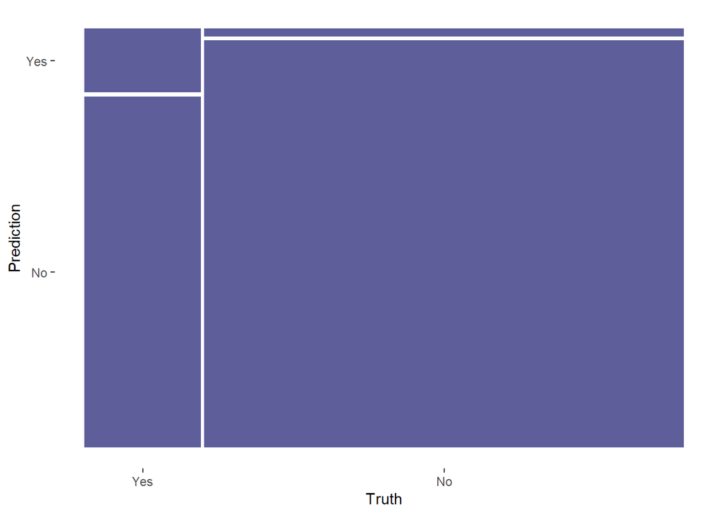

```r
#Visualise Results_RF
update_geom_defaults(geom = "rect", new = list(fill = "midnightblue", alpha = 0.7))
results_RF%>%
  conf_mat(GDDiag,.pred_class) %>%
  autoplot()
```

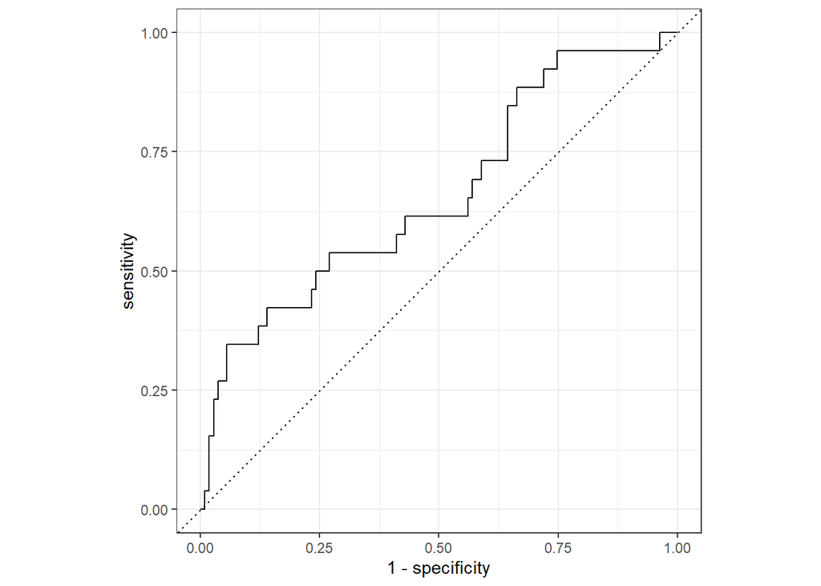

```r
#Metrics
ev_met1_RF<-ev_met1(results_RF,truth = GDDiag, estimate = .pred_class)
Rec_RF<-yardstick::recall(results_RF, GDDiag, .pred_class)
ACC_RF<-yardstick::accuracy(results_RF, GDDiag, .pred_class)
#Plot Roc_Curve
curve_RF <- results_RF %>%
  roc_curve(GDDiag, .pred_Yes) %>%
  autoplot
curve_RF
```

```r
#Evaluate AUC
auc_RF <- results_RF %>%
  roc_auc(GDDiag, .pred_Yes)
RFMET<-list(auc_RF,ev_met1_RF, Rec_RF, ACC_RF)
kable(RFMET)
```

| .metric | .estimator | .estimate |
| --- | --- | --- |
| roc_auc | binary | 0.659 |

| .metric | .estimator | .estimate |
| --- | --- | --- |
| ppv | binary | 0.667 |
| f_meas | binary | 0.250 |

| .metric | .estimator | .estimate |
| --- | --- | --- |
| recall | binary | 0.154 |

| .metric | .estimator | .estimate |
| --- | --- | --- |
| accuracy | binary | 0.82 |

```
## [[1]]
## [[1]][[1]]
## # A tibble: 1 x 3
##   .metric .estimator .estimate
##   <chr>   <chr>          <dbl>
## 1 roc_auc binary         0.659
##
## [[1]][[2]]
## # A tibble: 2 x 3
##   .metric .estimator .estimate
##   <chr>   <chr>          <dbl>
## 1 ppv     binary         0.667
## 2 f_meas  binary         0.25
##
## [[1]][[3]]
## # A tibble: 1 x 3
##   .metric .estimator .estimate
##   <chr>   <chr>          <dbl>
## 1 recall  binary         0.154
##
## [[1]][[4]]
## # A tibble: 1 x 3
##   .metric  .estimator .estimate
##   <chr>    <chr>          <dbl>
## 1 accuracy binary         0.820
##
##
## [[2]]
```

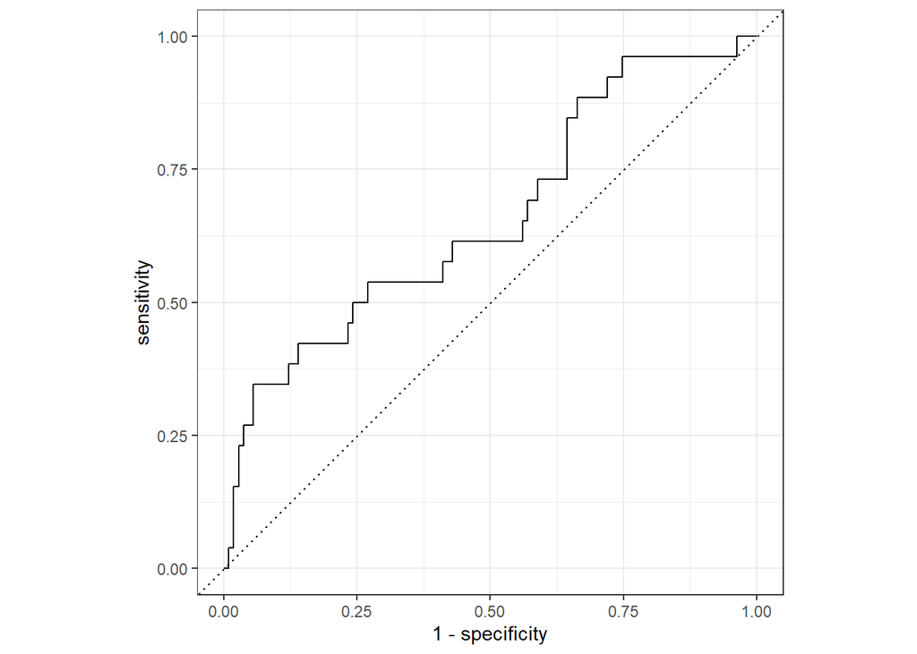

```r
RFMETCurVe<-list(RFMET, curve_RF)
RFMETCurVe
```

```r
#LogReg_Untuned_workflow

results_LR%>%
  conf_mat(truth = GDDiag, estimate = .pred_class)
```

```
##           Truth
## Prediction Yes  No
##        Yes   2   0
##        No   24 107
```

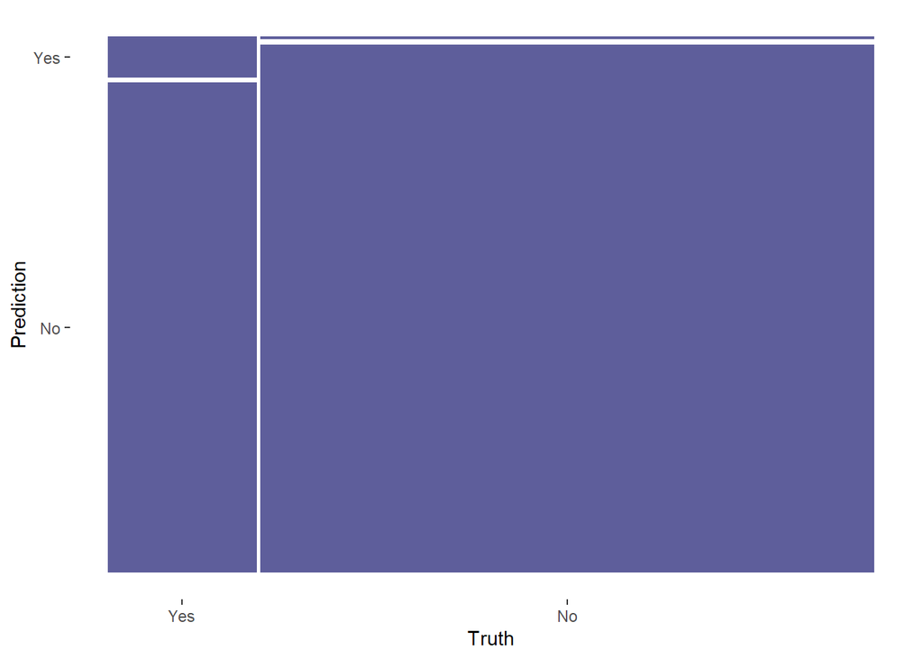

```r
#Visualise Results_RF
update_geom_defaults(geom = "rect", new = list(fill = "midnightblue", alpha = 0.7))
results_LR%>%
  conf_mat(GDDiag,.pred_class) %>%
  autoplot()
```

```r
#Metrics
ev_met1_LR<-ev_met1(results_LR,truth = GDDiag, estimate = .pred_class)
Rec_LR<-yardstick::recall(results_LR, GDDiag, .pred_class)
ACC_LR<-yardstick::accuracy(results_LR, GDDiag, .pred_class)
#Plot Roc_Curve
curve_LR <- results_LR %>%
  roc_curve(GDDiag, .pred_Yes) %>%
  autoplot
curve_LR
```

```r
#Evaluate AUC
auc_LR <- results_LR %>%
  roc_auc(GDDiag, .pred_Yes)
LRMET<-list(auc_LR,ev_met1_LR, Rec_LR, ACC_LR)
kable(LRMET)
```

| .metric | .estimator | .estimate |
| --- | --- | --- |
| roc_auc | binary | 0.723 |

| .metric | .estimator | .estimate |
| --- | --- | --- |
| ppv | binary | 1.000 |
| f_meas | binary | 0.143 |

| .metric | .estimator | .estimate |
| --- | --- | --- |
| recall | binary | 0.077 |

| .metric | .estimator | .estimate |
| --- | --- | --- |
| accuracy | binary | 0.82 |

```r
LRMETCurVe<-list(LRMET, curve_LR)
LRMETCurVe
```

```
## [[1]]
## [[1]][[1]]
## # A tibble: 1 x 3
##   .metric .estimator .estimate
##   <chr>   <chr>          <dbl>
## 1 roc_auc binary         0.723
##
## [[1]][[2]]
## # A tibble: 2 x 3
##   .metric .estimator .estimate
##   <chr>   <chr>          <dbl>
## 1 ppv     binary         1
## 2 f_meas  binary         0.143
##
## [[1]][[3]]
## # A tibble: 1 x 3
##   .metric .estimator .estimate
##   <chr>   <chr>          <dbl>
## 1 recall  binary        0.0769
##
## [[1]][[4]]
## # A tibble: 1 x 3
##   .metric  .estimator .estimate
##   <chr>    <chr>          <dbl>
## 1 accuracy binary         0.820
##
##
## [[2]]
```

```r
#Kernel_SMV_Untuned
results_Kern%>%
  conf_mat(truth = GDDiag, estimate = .pred_class)
```

```
##           Truth
## Prediction Yes  No
##        Yes   0   0
##        No   26 107
```

```r
#Visualise Results_RF
update_geom_defaults(geom = "rect", new = list(fill = "midnightblue", alpha = 0.7))
results_Kern%>%
  conf_mat(GDDiag,.pred_class) %>%
  autoplot()
```

```r
#Metrics
ev_met1_Kern<-ev_met1(results_Kern,truth = GDDiag, estimate = .pred_class)
```

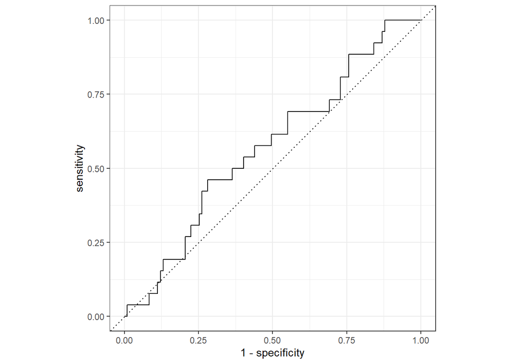

```r
Rec_Kern<-yardstick::recall(results_Kern, GDDiag, .pred_class)
ACC_Kern<-yardstick::accuracy(results_Kern, GDDiag, .pred_class)
#Plot Roc_Curve
curve_Kern <- results_Kern %>%
  roc_curve(GDDiag, .pred_Yes) %>%
  autoplot
curve_Kern
```

```r
#Evaluate AUC
auc_Kern <- results_Kern %>%
  roc_auc(GDDiag, .pred_Yes)
KernMET<-list(auc_Kern,ev_met1_Kern, Rec_Kern, ACC_Kern)
kable(KernMET)
```

| .metric | .estimator | .estimate |
| --- | --- | --- |
| roc_auc | binary | 0.569 |

| .metric | .estimator | .estimate |
| --- | --- | --- |
| ppv | binary | NaN |
| f_meas | binary | NA |

| .metric | .estimator | .estimate |
| --- | --- | --- |
| recall | binary | 0 |

| .metric | .estimator | .estimate |
| --- | --- | --- |
| accuracy | binary | 0.805 |

```r
KernMETCurVe<-list(KernMET, curve_LR)
KernMETCurVe
```

```
## [[1]]
## [[1]][[1]]
## # A tibble: 1 x 3
##   .metric .estimator .estimate
##   <chr>   <chr>          <dbl>
## 1 roc_auc binary         0.569
##
## [[1]][[2]]
## # A tibble: 2 x 3
##   .metric .estimator .estimate
##   <chr>   <chr>          <dbl>
## 1 ppv     binary           NaN
## 2 f_meas  binary            NA
##
## [[1]][[3]]
## # A tibble: 1 x 3
##   .metric .estimator .estimate
##   <chr>   <chr>          <dbl>
## 1 recall  binary             0
##
## [[1]][[4]]
## # A tibble: 1 x 3
##   .metric  .estimator .estimate
##   <chr>    <chr>          <dbl>
## 1 accuracy binary         0.805
##
##
## [[2]]
```

```r
#NB_Untuned
results_NB%>%
  conf_mat(truth = GDDiag, estimate = .pred_class)
```

```
##           Truth
## Prediction Yes  No
##        Yes   2   2
##        No   24 105
```

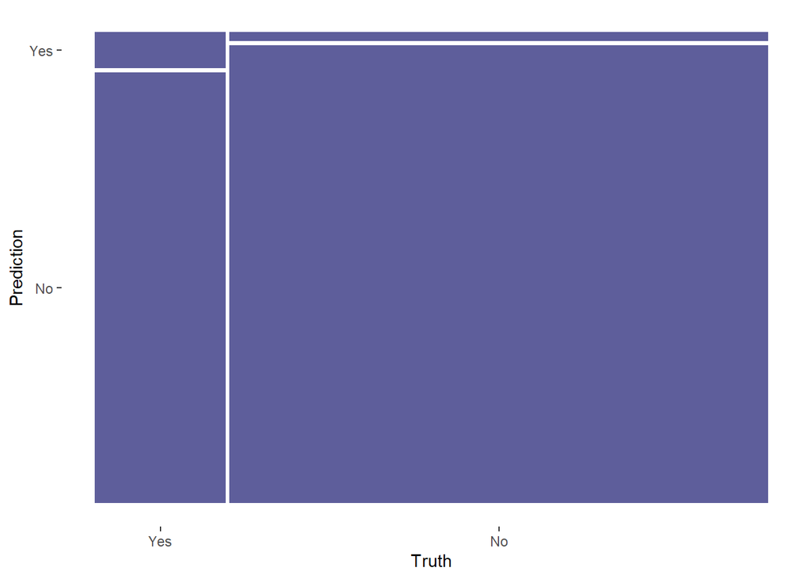

```r
#Visualise Results_RF
update_geom_defaults(geom = "rect", new = list(fill = "midnightblue", alpha = 0.7))
results_NB%>%
  conf_mat(GDDiag,.pred_class) %>%
  autoplot()
```

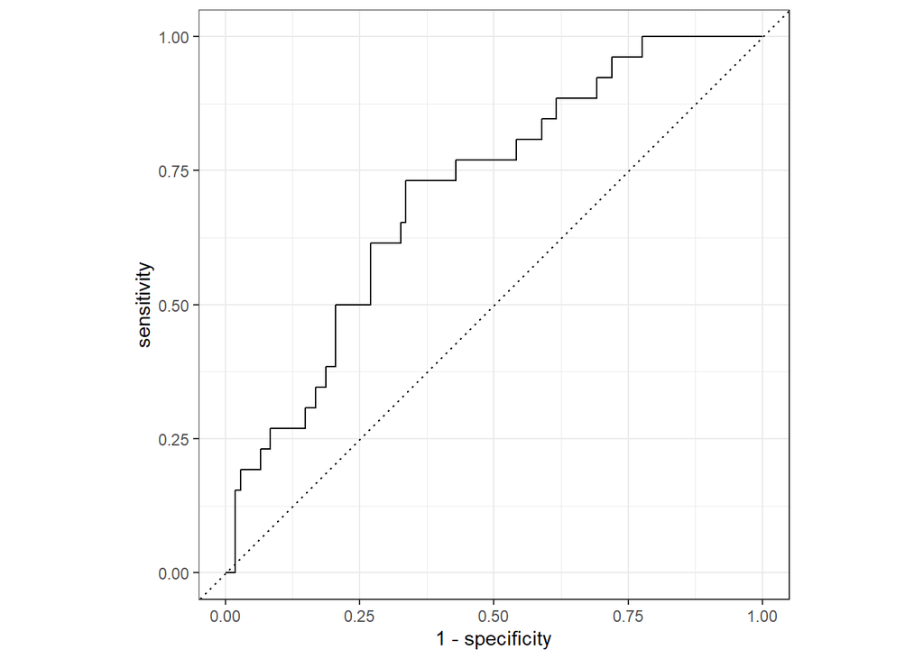

```r
#Metrics
ev_met1_NB<-ev_met1(results_NB,truth = GDDiag, estimate = .pred_class)
Rec_NB<-yardstick::recall(results_NB, GDDiag, .pred_class)
ACC_NB<-yardstick::accuracy(results_NB, GDDiag, .pred_class)
#Plot Roc_Curve
curve_NB <- results_NB %>%
  roc_curve(GDDiag, .pred_Yes) %>%
  autoplot
curve_NB
```

```r
#Evaluate AUC
auc_NB <- results_NB %>%
  roc_auc(GDDiag, .pred_Yes)
NBMET<-list(auc_NB,ev_met1_NB, Rec_NB, ACC_NB)
kable(NBMET)
```

| .metric | .estimator | .estimate |
| --- | --- | --- |
| roc_auc | binary | 0.71 |

| .metric | .estimator | .estimate |
| --- | --- | --- |
| ppv | binary | 0.500 |
| f_meas | binary | 0.133 |

| .metric | .estimator | .estimate |
| --- | --- | --- |
| recall | binary | 0.077 |

| .metric | .estimator | .estimate |
| --- | --- | --- |
| accuracy | binary | 0.805 |

```
## [[1]]
## [[1]][[1]]
## # A tibble: 1 x 3
##   .metric .estimator .estimate
##   <chr>   <chr>          <dbl>
## 1 roc_auc binary         0.710
##
## [[1]][[2]]
## # A tibble: 2 x 3
##   .metric .estimator .estimate
##   <chr>   <chr>          <dbl>
## 1 ppv     binary         0.5
## 2 f_meas  binary         0.133
##
## [[1]][[3]]
## # A tibble: 1 x 3
##   .metric .estimator .estimate
##   <chr>   <chr>          <dbl>
## 1 recall  binary        0.0769
##
## [[1]][[4]]
## # A tibble: 1 x 3
##   .metric  .estimator .estimate
##   <chr>    <chr>          <dbl>
## 1 accuracy binary         0.805
##
##
## [[2]]
```

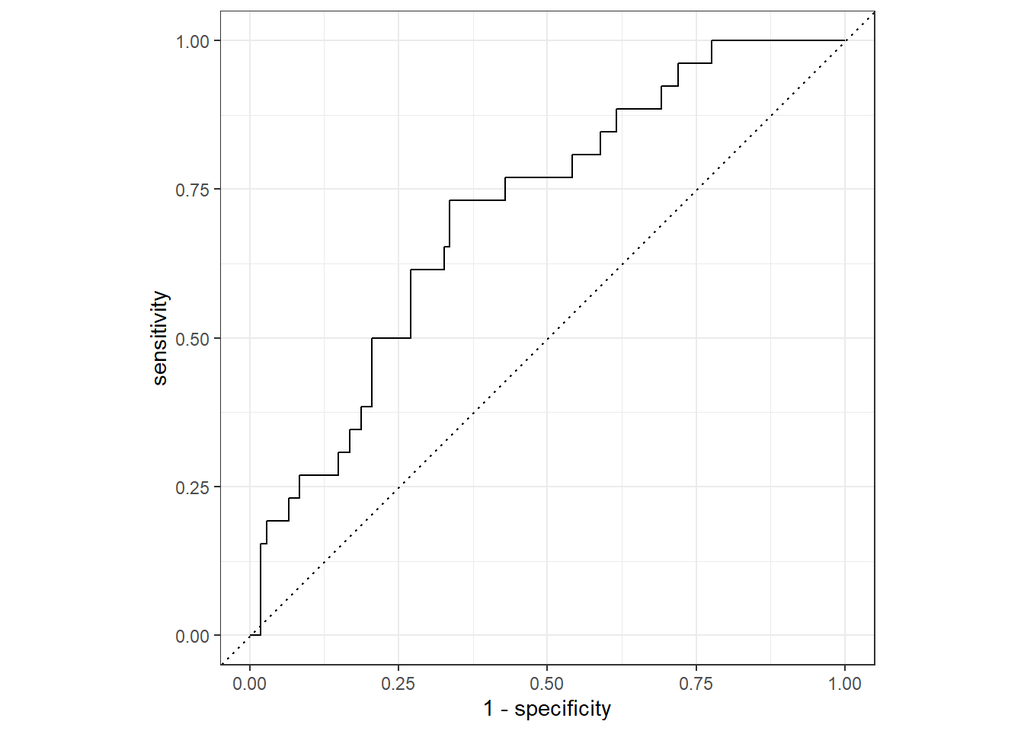

```r
NBMETCurVe<-list(NBMET, curve_NB)
NBMETCurVe
```

Fitting the different workflows on the testing data and extracting the most importnat recipe predictors for the different workflows for models available

```r
echo=FALSE
error=FALSE
warning=FALSE
options(scipen = 999, digits=3, max.print=999999, show.signif.stars=TRUE)
Null_fit_Test<-Null_workflow%>%fit(test_data_GD_b)
Null_fit_Test
```

```
## == Workflow [trained] ==========================================================
## Preprocessor: Recipe
## Model: null_model()
##
## -- Preprocessor ----------------------------------------------------------------
## 5 Recipe Steps
##
## * step_smote()
## * step_zv()
## * step_nzv()
## * step_corr()
## * step_normalize()
##
## -- Model -----------------------------------------------------------------------
## Null Regression Model
## Predicted Value: No
```

```r
Lasso_fit_Test<-lasso_workflow%>%fit(test_data_GD_b)
Lasso_fit_Test
```

```
## == Workflow [trained] ==========================================================
## Preprocessor: Recipe
## Model: multinom_reg()
##
## -- Preprocessor ----------------------------------------------------------------
## 5 Recipe Steps
##
## * step_smote()
## * step_zv()
## * step_nzv()
## * step_corr()
## * step_normalize()
##
## -- Model -----------------------------------------------------------------------
##
```

[output cut: 52 more lines]

```r
RF_fit_Test<-RF_workflow%>%fit(test_data_GD_b)
RF_fit_Test
```

```
## == Workflow [trained] ==========================================================
## Preprocessor: Recipe
## Model: rand_forest()
##
## -- Preprocessor ----------------------------------------------------------------
## 5 Recipe Steps
##
## * step_smote()
## * step_zv()
## * step_nzv()
## * step_corr()
## * step_normalize()
##
## -- Model -----------------------------------------------------------------------
## Ranger result
##
## Call:
##  ranger::ranger(x = maybe_data_frame(x), y = y, importance = ~"impurity",      num.threads = 1, verbose = FALSE, seed = sample.int(10^5,          1), probability = TRUE)
##
## Type:                             Probability estimation
## Number of trees:                  500
## Sample size:                      133
## Number of independent variables:  6
## Mtry:                             2
## Target node size:                 10
## Variable importance mode:         impurity
## Splitrule:                        gini
## OOB prediction error (Brier s.):  0.145
```

```r
LogReg_fit_Test<-LOGGLM_workflow%>%fit(test_data_GD_b)
LogReg_fit_Test
```

```
## == Workflow [trained] ==========================================================
## Preprocessor: Recipe
## Model: logistic_reg()
##
## -- Preprocessor ----------------------------------------------------------------
## 5 Recipe Steps
##
## * step_smote()
## * step_zv()
## * step_nzv()
## * step_corr()
## * step_normalize()
##
## -- Model -----------------------------------------------------------------------
##
## Call:  stats::glm(formula = ..y ~ ., family = stats::binomial, data = data)
##
## Coefficients:
## (Intercept)          AGE    Gameyears      IDTotal      IMTotal    COMPTotal
##      1.6974       0.2494       0.2032       0.4399      -1.1851       0.0143
##     PETotal
##      0.4670
##
## Degrees of Freedom: 132 Total (i.e. Null);  126 Residual
## Null Deviance:       131
## Residual Deviance: 113   AIC: 127
```

```r
Kernel_fit_Test<-Kernel_workflow%>%fit(test_data_GD_b)
Kernel_fit_Test
```

```
## == Workflow [trained] ==========================================================
## Preprocessor: Recipe
## Model: svm_rbf()
##
## -- Preprocessor ----------------------------------------------------------------
## 5 Recipe Steps
##
## * step_smote()
## * step_zv()
## * step_nzv()
## * step_corr()
## * step_normalize()
##
## -- Model -----------------------------------------------------------------------
## Support Vector Machine object of class "ksvm"
##
## SV type: C-svc  (classification)
##  parameter : cost C = 1
##
## Gaussian Radial Basis kernel function.
##  Hyperparameter : sigma =  0.01
##
## Number of Support Vectors : 63
##
## Objective Function Value : -52
## Training error : 0.195489
## Probability model included.
```

```r
NB_fit_Test<-NB_workflow%>%fit(test_data_GD_b)
NB_fit_Test
```

```
## == Workflow [trained] ==========================================================
## Preprocessor: Recipe
## Model: naive_Bayes()
##
## -- Preprocessor ----------------------------------------------------------------
## 5 Recipe Steps
##
## * step_smote()
## * step_zv()
## * step_nzv()
## * step_corr()
## * step_normalize()
##
## -- Model -----------------------------------------------------------------------
##
## ================================== Naive Bayes ==================================
##
##  Call:
## naive_bayes.default(x = maybe_data_frame(x), y = y, usekernel = TRUE)
##
## ---------------------------------------------------------------------------------
##
## Laplace smoothing: 0
##
## ---------------------------------------------------------------------------------
##
##  A priori probabilities:
##
##   Yes    No
## 0.195 0.805
##
## ---------------------------------------------------------------------------------
##
##  Tables:
##
## ---------------------------------------------------------------------------------
##  ::: AGE::Yes (KDE)
## ---------------------------------------------------------------------------------
##
## Call:
```

[output cut: 12 more lines]

```
## ---------------------------------------------------------------------------------
##  ::: AGE::No (KDE)
## ---------------------------------------------------------------------------------
##
## Call:
##  density.default(x = x, na.rm = TRUE)
##
## Data: x (107 obs.);  Bandwidth 'bw' = 0.354
##
##        x               y
##  Min.   :-2.70   Min.   :0.000
##  1st Qu.:-1.08   1st Qu.:0.030
##
## ...
## and 147 more lines.
```

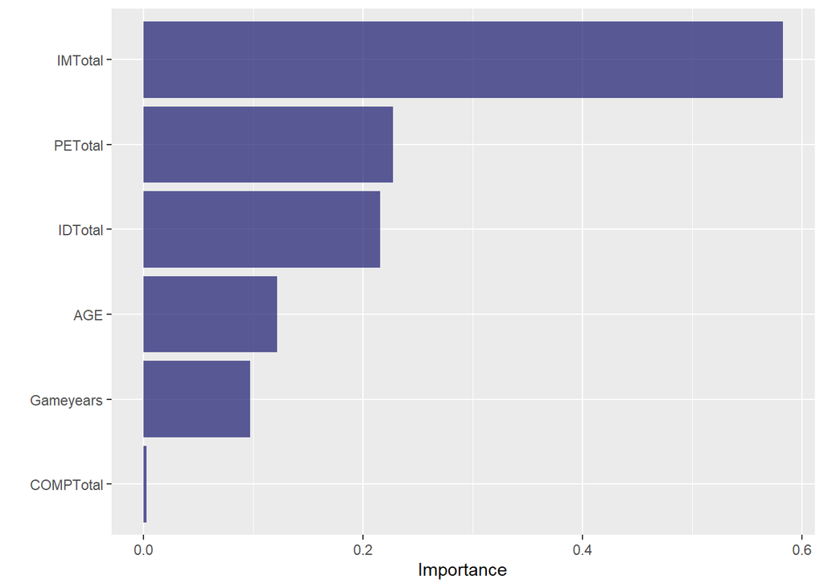

```r
Lasso_fit_Test %>%
  extract_fit_parsnip() %>%
 #Make VIP plot
 vip()
```

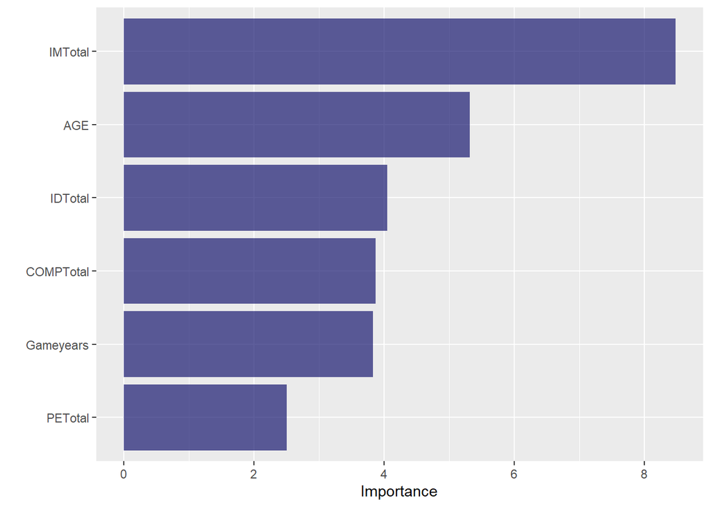

```r
RF_fit_Test %>%
  extract_fit_parsnip() %>%
 #Make VIP plot
 vip()
```

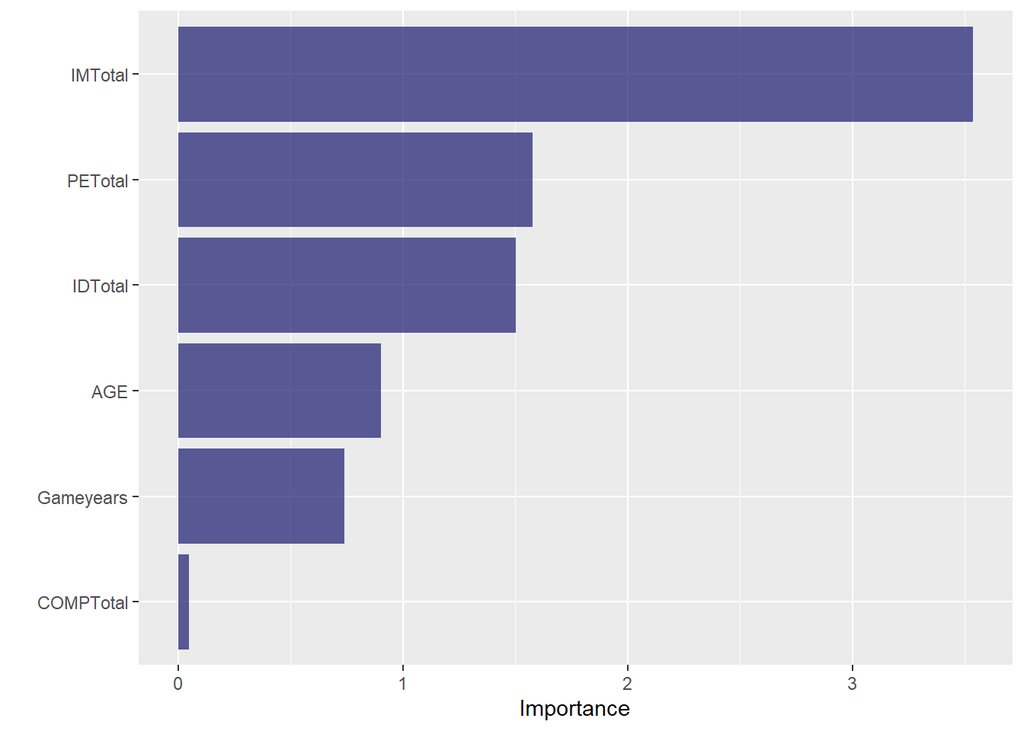

```r
LogReg_fit_Test %>%
  extract_fit_parsnip() %>%
 #Make VIP plot
 vip()
```

Tune Tunable Predictors RF, Kernel, Lasso, Logistic Regression

#Tune Kernel Algorithm

```r
echo=FALSE
error=FALSE
warning=FALSE
options(scipen = 999, digits=3, max.print=999999, show.signif.stars=TRUE)
set.seed(123)
#Kernel
#first creating a tuning model
svm_spec_T <- svm_rbf(mode = "classification", engine = "kernlab", cost = tune(), rbf_sigma = tune())
#second creating a tuning workflow
Kernel_workflow_T<-workflow() %>%
  add_recipe(GD_rec) %>%
  add_model(svm_spec_T)
#third calling the workflow
Kernel_workflow_T
```

```
## == Workflow ====================================================================
## Preprocessor: Recipe
## Model: svm_rbf()
##
## -- Preprocessor ----------------------------------------------------------------
## 5 Recipe Steps
##
## * step_smote()
## * step_zv()
## * step_nzv()
## * step_corr()
## * step_normalize()
##
## -- Model -----------------------------------------------------------------------
## Radial Basis Function Support Vector Machine Model Specification (classification)
##
## Main Arguments:
##   cost = tune()
##   rbf_sigma = tune()
##
## Computational engine: kernlab
```

```r
# fourth creating the regular grid of 6 values for each tuning parameters
svm_grid <- grid_regular(parameters(svm_spec_T), levels = 10)
#fifth calling the grid
svm_grid
```

```
## # A tibble: 100 x 2
##         cost    rbf_sigma
##        <dbl>        <dbl>
##  1  0.000977 0.0000000001
##  2  0.00310  0.0000000001
##  3  0.00984  0.0000000001
##  4  0.0312   0.0000000001
##  5  0.0992   0.0000000001
##  6  0.315    0.0000000001
##  7  1        0.0000000001
##  8  3.17     0.0000000001
##  9 10.1      0.0000000001
## 10 32        0.0000000001
## # i 90 more rows
```

```r
#sixth tuning the grid
svm_res <- tune_grid(
  object = Kernel_workflow_T,resamples = train_boot,
  grid = svm_grid
)
```

```r
#Seventh collect tuning metrics
svm_res %>%
  collect_metrics() %>%
  slice_head(n = 20)
```

```
## # A tibble: 20 x 8
##         cost    rbf_sigma .metric  .estimator  mean     n std_err .config
##        <dbl>        <dbl> <chr>    <chr>      <dbl> <int>   <dbl> <chr>
##  1  0.000977 0.0000000001 accuracy binary     0.806    25 0.00251 Preprocessor1~
##  2  0.000977 0.0000000001 roc_auc  binary     0.448    25 0.00929 Preprocessor1~
##  3  0.00310  0.0000000001 accuracy binary     0.806    25 0.00251 Preprocessor1~
##  4  0.00310  0.0000000001 roc_auc  binary     0.449    25 0.00932 Preprocessor1~
##  5  0.00984  0.0000000001 accuracy binary     0.806    25 0.00251 Preprocessor1~
##  6  0.00984  0.0000000001 roc_auc  binary     0.449    25 0.00930 Preprocessor1~
##  7  0.0312   0.0000000001 accuracy binary     0.806    25 0.00251 Preprocessor1~
##  8  0.0312   0.0000000001 roc_auc  binary     0.449    25 0.00930 Preprocessor1~
##  9  0.0992   0.0000000001 accuracy binary     0.806    25 0.00251 Preprocessor1~
## 10  0.0992   0.0000000001 roc_auc  binary     0.449    25 0.00931 Preprocessor1~
## 11  0.315    0.0000000001 accuracy binary     0.806    25 0.00251 Preprocessor1~
## 12  0.315    0.0000000001 roc_auc  binary     0.449    25 0.00931 Preprocessor1~
## 13  1        0.0000000001 accuracy binary     0.806    25 0.00251 Preprocessor1~
## 14  1        0.0000000001 roc_auc  binary     0.449    25 0.00931 Preprocessor1~
## 15  3.17     0.0000000001 accuracy binary     0.806    25 0.00251 Preprocessor1~
## 16  3.17     0.0000000001 roc_auc  binary     0.449    25 0.00931 Preprocessor1~
## 17 10.1      0.0000000001 accuracy binary     0.806    25 0.00251 Preprocessor1~
## 18 10.1      0.0000000001 roc_auc  binary     0.449    25 0.00931 Preprocessor1~
## 19 32        0.0000000001 accuracy binary     0.806    25 0.00251 Preprocessor1~
## 20 32        0.0000000001 roc_auc  binary     0.449    25 0.00931 Preprocessor1~
```

```r
  #show_best()
```

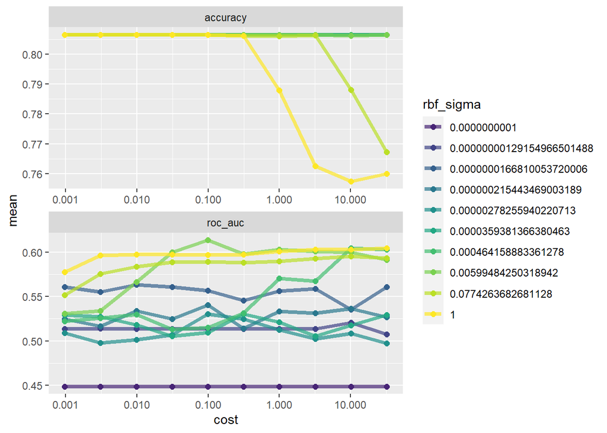

```r
  #Eighth Visualizing Tuning Metrics

svm_res %>%
  collect_metrics() %>%
  mutate(rbf_sigma = factor(rbf_sigma)) %>%
  ggplot(mapping = aes(x = cost, y = mean, color = rbf_sigma)) +
  geom_line(size = 1.5, alpha = 0.7) +
  geom_point(size = 2) +
  facet_wrap(~.metric, scales = "free", nrow = 2) +
  scale_x_log10(labels = scales::label_number()) +
  scale_color_viridis_d(option = "viridis", begin = .1)
```

```r
#Nineth show the best model
svm_res %>%
  show_best("accuracy")
```

```
## # A tibble: 5 x 8
##       cost    rbf_sigma .metric  .estimator  mean     n std_err .config
##      <dbl>        <dbl> <chr>    <chr>      <dbl> <int>   <dbl> <chr>
## 1 0.000977 0.0000000001 accuracy binary     0.806    25 0.00251 Preprocessor1_M~
## 2 0.00310  0.0000000001 accuracy binary     0.806    25 0.00251 Preprocessor1_M~
## 3 0.00984  0.0000000001 accuracy binary     0.806    25 0.00251 Preprocessor1_M~
## 4 0.0312   0.0000000001 accuracy binary     0.806    25 0.00251 Preprocessor1_M~
## 5 0.0992   0.0000000001 accuracy binary     0.806    25 0.00251 Preprocessor1_M~
```

```r
svm_res%>%
  show_best("roc_auc")
```

```
## # A tibble: 5 x 8
##      cost rbf_sigma .metric .estimator  mean     n std_err .config
##     <dbl>     <dbl> <chr>   <chr>      <dbl> <int>   <dbl> <chr>
## 1  0.0992  0.00599  roc_auc binary     0.614    25 0.00974 Preprocessor1_Model0~
## 2 10.1     0.000464 roc_auc binary     0.605    25 0.0133  Preprocessor1_Model0~
## 3 32       1        roc_auc binary     0.604    25 0.00955 Preprocessor1_Model1~
## 4  3.17    1        roc_auc binary     0.603    25 0.00973 Preprocessor1_Model0~
## 5  1       0.00599  roc_auc binary     0.603    25 0.0109  Preprocessor1_Model0~
```

```r
# Tenth Select best model hyperparameters
best_svm <- svm_res %>%
  select_best("accuracy", "roc_auc")
#11th Finalize the workoflow with the best SVM
final_wflow <- Kernel_workflow_T %>%
  finalize_workflow(best_svm)
#12th Check the fit of the final Wflow on the training data
Tuned_Kernel_fit<-final_wflow%>%fit(train_data_GD_b)
Tuned_Kernel_fit
```

```
## == Workflow [trained] ==========================================================
## Preprocessor: Recipe
## Model: svm_rbf()
##
## -- Preprocessor ----------------------------------------------------------------
## 5 Recipe Steps
##
## * step_smote()
## * step_zv()
## * step_nzv()
## * step_corr()
## * step_normalize()
##
## -- Model -----------------------------------------------------------------------
## Support Vector Machine object of class "ksvm"
##
## SV type: C-svc  (classification)
##  parameter : cost C = 0.0009765625
##
## Gaussian Radial Basis kernel function.
##  Hyperparameter : sigma =  0.0000000001
##
## Number of Support Vectors : 160
##
## Objective Function Value : -0.156
## Training error : 0.2
## Probability model included.
```

```r
#Test the tuned Kernel on the test data
results_tuned_Kern<-test_data_GD_b %>% select(GDDiag) %>%
  bind_cols (Tuned_Kernel_fit%>%
              predict(new_data = test_data_GD_b)) %>%
  bind_cols(Tuned_Kernel_fit%>%
              predict(new_data = test_data_GD_b, type = "prob"))
kable(results_tuned_Kern)
```

| GDDiag | .pred_class | .pred_Yes | .pred_No |
| --- | --- | --- | --- |
| Yes | No | 0.2 | 0.8 |
| No | No | 0.2 | 0.8 |
| No | No | 0.2 | 0.8 |
| No | No | 0.2 | 0.8 |
| No | No | 0.2 | 0.8 |
| No | No | 0.2 | 0.8 |
| No | No | 0.2 | 0.8 |
| No | No | 0.2 | 0.8 |
| No | No | 0.2 | 0.8 |
| No | No | 0.2 | 0.8 |
| No | No | 0.2 | 0.8 |
| No | No | 0.2 | 0.8 |
| No | No | 0.2 | 0.8 |
| No | No | 0.2 | 0.8 |
| No | No | 0.2 | 0.8 |
| No | No | 0.2 | 0.8 |
| No | No | 0.2 | 0.8 |
| No | No | 0.2 | 0.8 |
| No | No | 0.2 | 0.8 |
| No | No | 0.2 | 0.8 |
| No | No | 0.2 | 0.8 |
| No | No | 0.2 | 0.8 |
| No | No | 0.2 | 0.8 |
| No | No | 0.2 | 0.8 |
| No | No | 0.2 | 0.8 |
| No | No | 0.2 | 0.8 |
| No | No | 0.2 | 0.8 |
| Yes | No | 0.2 | 0.8 |
| No | No | 0.2 | 0.8 |
| No | No | 0.2 | 0.8 |

[output cut: 103 more lines]

```r
#Tuned Kernel_Results
results_tuned_Kern %>%
  conf_mat(truth = GDDiag, estimate = .pred_class)
```

```
##           Truth
## Prediction Yes  No
##        Yes   0   0
##        No   26 107
```

```r
#visualise CF
update_geom_defaults(geom = "rect", new = list(fill = "midnightblue", alpha = 0.7))
results_tuned_Kern %>%
  conf_mat(GDDiag, .pred_class) %>%
  autoplot()
```

[output not shown]

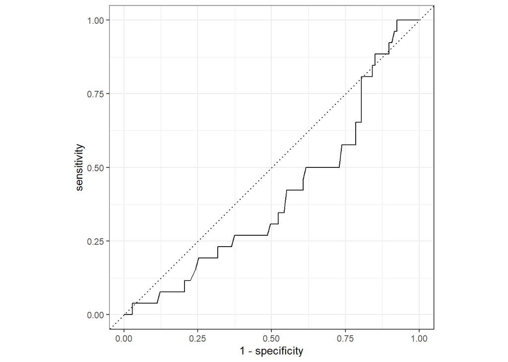

```r
#Plot Roc_Curve
curve_kern_tuned <- results_tuned_Kern%>%
  roc_curve(GDDiag, .pred_Yes)%>%
  autoplot

curve_kern_tuned
```

```r
# Evaluate ROC_AUC
auc_kern_tuned <- results_tuned_Kern %>%
  roc_auc(GDDiag, .pred_Yes)
auc_kern_tuned
```

```
## # A tibble: 1 x 3
##   .metric .estimator .estimate
##   <chr>   <chr>          <dbl>
## 1 roc_auc binary         0.403
```

```r
#AUC, PPV, ACC, Recall, Fmeas
ev_met1_TunKern<-ev_met1(results_tuned_Kern,truth = GDDiag, estimate = .pred_class)
Rec_TK<-yardstick::recall(results_tuned_Kern, GDDiag, .pred_class)
ACC_TK<-yardstick::accuracy(results_tuned_Kern, GDDiag, .pred_class)
TunKernMET<-list(auc_kern_tuned,ev_met1_TunKern, Rec_TK, ACC_TK)
kable(TunKernMET)
```

| .metric | .estimator | .estimate |
| --- | --- | --- |
| roc_auc | binary | 0.403 |

| .metric | .estimator | .estimate |
| --- | --- | --- |
| ppv | binary | NaN |
| f_meas | binary | NA |

| .metric | .estimator | .estimate |
| --- | --- | --- |
| recall | binary | 0 |

| .metric | .estimator | .estimate |
| --- | --- | --- |
| accuracy | binary | 0.805 |

Tune Random Forests

```r
set.seed(123)
#RF
#first creating a tuning model
ranger_spec_T <- rand_forest(
  mtry = tune(),
  trees = 1000,
  min_n = tune()
)%>%
  set_mode("classification")%>%
  set_engine("ranger")
#second creating a tuning workflow
RF_workflow_T<-workflow() %>%
  add_recipe(GD_rec) %>%
  add_model(ranger_spec_T)
#third calling the workflow
RF_workflow_T
```

```
## == Workflow ====================================================================
## Preprocessor: Recipe
## Model: rand_forest()
##
## -- Preprocessor ----------------------------------------------------------------
## 5 Recipe Steps
##
## * step_smote()
## * step_zv()
## * step_nzv()
## * step_corr()
## * step_normalize()
##
## -- Model -----------------------------------------------------------------------
## Random Forest Model Specification (classification)
##
## Main Arguments:
##   mtry = tune()
##   trees = 1000
##   min_n = tune()
##
## Computational engine: ranger
```

```r
# fourth tuning/testing the workflow to the resamples
set.seed(345)
RF_res <- tune_grid(
  RF_workflow_T,
  resamples = folds,
  grid = 20
)
```

```
## i Creating pre-processing data to finalize unknown parameter: mtry
```

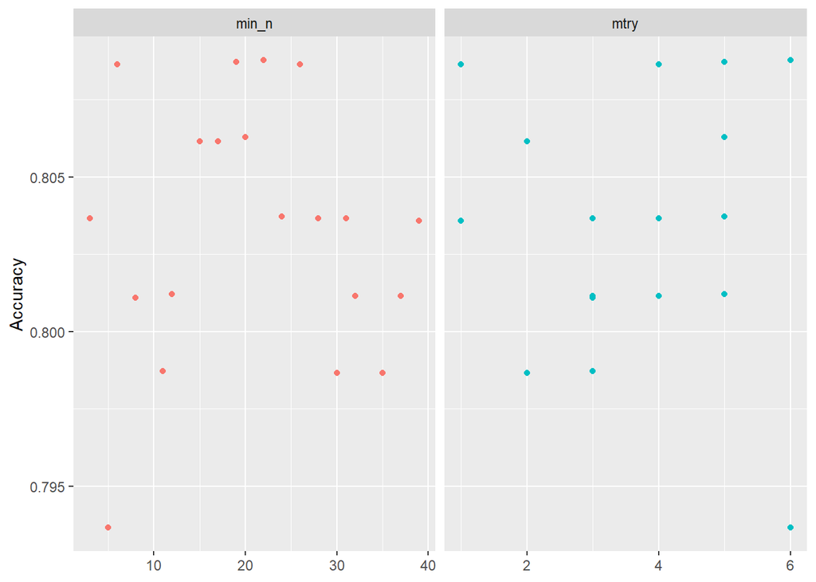

```r
#Fifth collect and visualize tuning metrics
RF_res %>%
  collect_metrics() %>%
  filter(.metric == "accuracy") %>%
  select(mean, min_n, mtry) %>%
  pivot_longer(min_n:mtry,
    values_to = "value",
    names_to = "parameter"
  )%>%
  ggplot(aes(value, mean, color = parameter)) +
  geom_point(show.legend = FALSE) +
  facet_wrap(~parameter, scales = "free_x") +
  labs(x = NULL, y = "Accuracy")
```

```r
#Fifth for collecting tuning metrics
RF_res %>%
  collect_metrics() %>%
  slice_head(n = 10)
```

```
## # A tibble: 10 x 8
##     mtry min_n .metric  .estimator  mean     n std_err .config
##    <int> <int> <chr>    <chr>      <dbl> <int>   <dbl> <chr>
##  1     2    35 accuracy binary     0.799    10  0.0270 Preprocessor1_Model01
##  2     2    35 roc_auc  binary     0.668    10  0.0240 Preprocessor1_Model01
##  3     5    19 accuracy binary     0.809    10  0.0234 Preprocessor1_Model02
##  4     5    19 roc_auc  binary     0.657    10  0.0342 Preprocessor1_Model02
##  5     4    37 accuracy binary     0.801    10  0.0276 Preprocessor1_Model03
##  6     4    37 roc_auc  binary     0.654    10  0.0270 Preprocessor1_Model03
##  7     5    20 accuracy binary     0.806    10  0.0230 Preprocessor1_Model04
##  8     5    20 roc_auc  binary     0.662    10  0.0329 Preprocessor1_Model04
##  9     3    32 accuracy binary     0.801    10  0.0276 Preprocessor1_Model05
## 10     3    32 roc_auc  binary     0.658    10  0.0274 Preprocessor1_Model05
```

```r
#Nineth show the best model
RF_res %>%
  show_best("accuracy", "roc_auc")
```

```
## # A tibble: 20 x 8
##     mtry min_n .metric  .estimator  mean     n std_err .config
##    <int> <int> <chr>    <chr>      <dbl> <int>   <dbl> <chr>
##  1     6    22 accuracy binary     0.809    10  0.0225 Preprocessor1_Model16
##  2     5    19 accuracy binary     0.809    10  0.0234 Preprocessor1_Model02
##  3     1     6 accuracy binary     0.809    10  0.0266 Preprocessor1_Model08
##  4     4    26 accuracy binary     0.809    10  0.0229 Preprocessor1_Model12
##  5     5    20 accuracy binary     0.806    10  0.0230 Preprocessor1_Model04
##  6     2    17 accuracy binary     0.806    10  0.0243 Preprocessor1_Model06
##  7     2    15 accuracy binary     0.806    10  0.0254 Preprocessor1_Model17
##  8     5    24 accuracy binary     0.804    10  0.0233 Preprocessor1_Model15
##  9     4    28 accuracy binary     0.804    10  0.0242 Preprocessor1_Model09
## 10     4    31 accuracy binary     0.804    10  0.0259 Preprocessor1_Model10
## 11     3     3 accuracy binary     0.804    10  0.0280 Preprocessor1_Model14
## 12     1    39 accuracy binary     0.804    10  0.0297 Preprocessor1_Model07
## 13     5    12 accuracy binary     0.801    10  0.0226 Preprocessor1_Model20
## 14     4    37 accuracy binary     0.801    10  0.0276 Preprocessor1_Model03
## 15     3    32 accuracy binary     0.801    10  0.0276 Preprocessor1_Model05
## 16     3     8 accuracy binary     0.801    10  0.0280 Preprocessor1_Model19
## 17     3    11 accuracy binary     0.799    10  0.0239 Preprocessor1_Model13
## 18     2    35 accuracy binary     0.799    10  0.0270 Preprocessor1_Model01
## 19     2    30 accuracy binary     0.799    10  0.0270 Preprocessor1_Model11
## 20     6     5 accuracy binary     0.794    10  0.0277 Preprocessor1_Model18
```

```r
# Tenth Select best model hyperparameters
best_RF <- RF_res %>%
  select_best("accuracy", "roc_auc")
best_RF
```

```
## # A tibble: 1 x 3
##    mtry min_n .config
##   <int> <int> <chr>
## 1     6    22 Preprocessor1_Model16
```

```r
#11th Finalize the workoflow with the best SVM
final_wflow_RF <- RF_workflow_T %>%
  finalize_workflow(best_RF)
#12th Check the fit of the final Wflow on the training data
Tuned_RF_fit<-final_wflow_RF%>%fit(train_data_GD_b)
Tuned_RF_fit
```

```
## == Workflow [trained] ==========================================================
## Preprocessor: Recipe
## Model: rand_forest()
##
## -- Preprocessor ----------------------------------------------------------------
## 5 Recipe Steps
##
## * step_smote()
## * step_zv()
## * step_nzv()
## * step_corr()
## * step_normalize()
##
## -- Model -----------------------------------------------------------------------
## Ranger result
##
## Call:
##  ranger::ranger(x = maybe_data_frame(x), y = y, mtry = min_cols(~6L,      x), num.trees = ~1000, min.node.size = min_rows(~22L, x),      num.threads = 1, verbose = FALSE, seed = sample.int(10^5,          1), probability = TRUE)
##
## Type:                             Probability estimation
## Number of trees:                  1000
## Sample size:                      400
## Number of independent variables:  6
## Mtry:                             6
## Target node size:                 22
## Variable importance mode:         none
## Splitrule:                        gini
## OOB prediction error (Brier s.):  0.152
```

```r
#Test the tuned RF on the test data
results_tuned_RF<-test_data_GD_b %>% select(GDDiag) %>%
  bind_cols (Tuned_RF_fit%>%
              predict(new_data = test_data_GD_b)) %>%
  bind_cols(Tuned_RF_fit%>%
              predict(new_data = test_data_GD_b, type = "prob"))
kable(results_tuned_RF)
```

| GDDiag | .pred_class | .pred_Yes | .pred_No |
| --- | --- | --- | --- |
| Yes | Yes | 0.523 | 0.477 |
| No | No | 0.192 | 0.808 |
| No | No | 0.314 | 0.686 |
| No | No | 0.018 | 0.982 |
| No | No | 0.060 | 0.940 |
| No | No | 0.377 | 0.623 |
| No | No | 0.195 | 0.805 |
| No | No | 0.187 | 0.813 |
| No | No | 0.159 | 0.841 |
| No | No | 0.283 | 0.717 |
| No | No | 0.036 | 0.964 |
| No | No | 0.220 | 0.780 |
| No | No | 0.215 | 0.785 |
| No | No | 0.200 | 0.800 |
| No | No | 0.184 | 0.816 |
| No | No | 0.137 | 0.863 |
| No | No | 0.159 | 0.841 |
| No | No | 0.040 | 0.960 |
| No | No | 0.172 | 0.828 |
| No | No | 0.017 | 0.983 |
| No | No | 0.071 | 0.929 |
| No | No | 0.227 | 0.773 |
| No | No | 0.300 | 0.700 |
| No | No | 0.233 | 0.767 |
| No | No | 0.169 | 0.831 |
| No | No | 0.212 | 0.788 |
| No | No | 0.098 | 0.902 |
| Yes | Yes | 0.524 | 0.476 |
| No | No | 0.016 | 0.984 |
| No | No | 0.167 | 0.833 |

[output cut: 103 more lines]

```r
#Tuned RF_Results
results_tuned_RF %>%
  conf_mat(truth = GDDiag, estimate = .pred_class)
```

```
##           Truth
## Prediction Yes  No
##        Yes   6   4
##        No   20 103
```

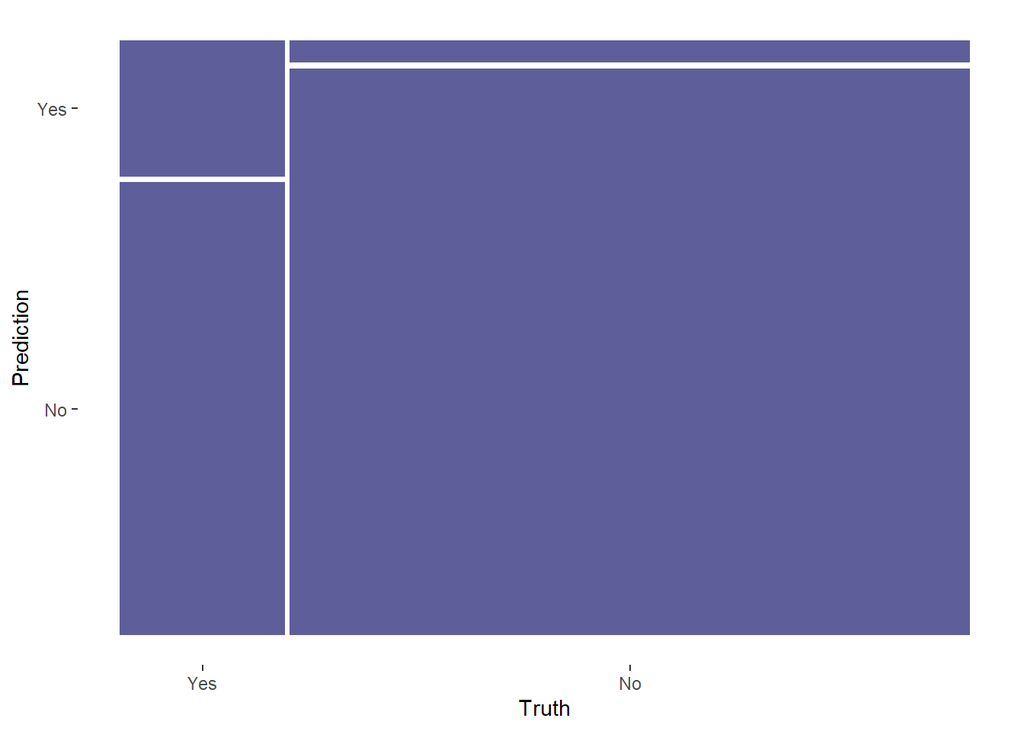

```r
#visualise CF
update_geom_defaults(geom = "rect", new = list(fill = "midnightblue", alpha = 0.7))
results_tuned_RF %>%
  conf_mat(GDDiag, .pred_class) %>%
  autoplot()
```

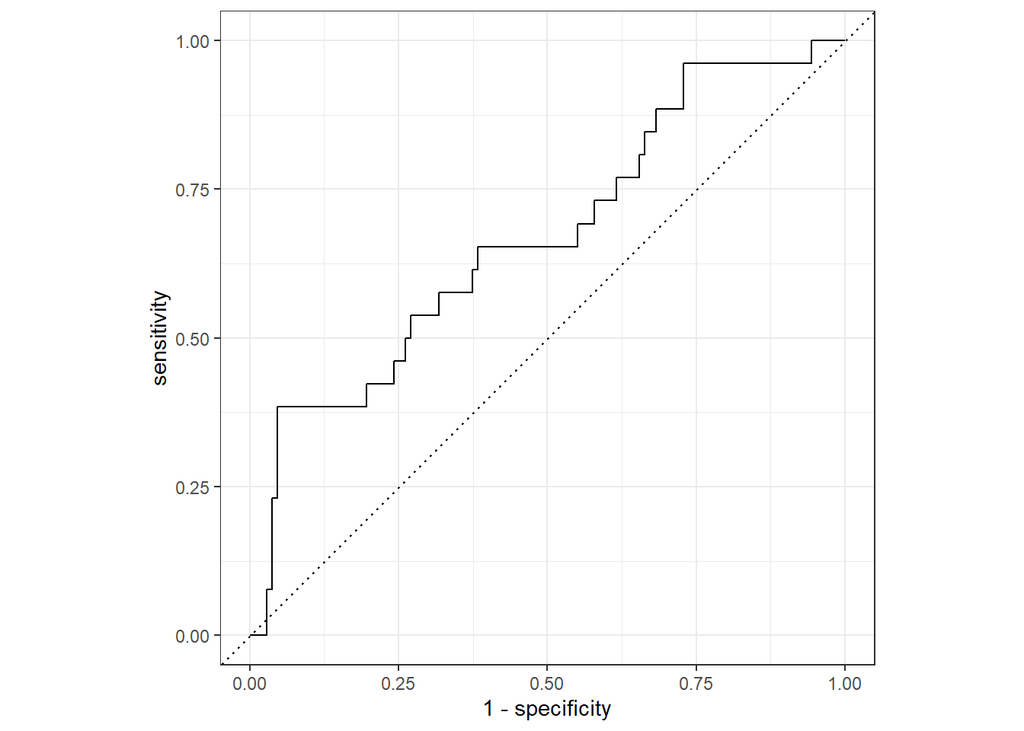

```r
#Plot Roc_Curve
curve_RF_tuned <- results_tuned_RF %>%
  roc_curve(GDDiag, .pred_Yes) %>%
  autoplot
curve_RF_tuned
```

```r
# Evaluate ROC_AOC
auc_RF_tuned <- results_tuned_RF %>%
  roc_auc(GDDiag, .pred_Yes)
ev_met1_TunRF<-ev_met1(results_tuned_RF,truth = GDDiag, estimate = .pred_class)
Rec_TRF<-yardstick::recall(results_tuned_RF, GDDiag, .pred_class)
ACC_TRF<-yardstick::accuracy(results_tuned_RF, GDDiag, .pred_class)
TunRFMET<-list(auc_RF_tuned,ev_met1_TunRF, Rec_TRF, ACC_TRF)
kable(TunRFMET)
```

| .metric | .estimator | .estimate |
| --- | --- | --- |
| roc_auc | binary | 0.67 |

| .metric | .estimator | .estimate |
| --- | --- | --- |
| ppv | binary | 0.600 |
| f_meas | binary | 0.333 |

| .metric | .estimator | .estimate |
| --- | --- | --- |
| recall | binary | 0.231 |

| .metric | .estimator | .estimate |
| --- | --- | --- |
| accuracy | binary | 0.82 |

#Tune Lasso

```r
set.seed(123)
#LASSO

#first creating a tuning model
tune_Lasso <- multinom_reg(penalty =tune(), mixture = 1)%>%
  set_mode("classification")%>%
  set_engine("glmnet")

#second creating a tuning workflow
Lasso_workflow_T<-workflow()%>%
  add_recipe(GD_rec) %>%
  add_model(tune_Lasso)
#third calling the workflow
Lasso_workflow_T
```

```
## == Workflow ====================================================================
## Preprocessor: Recipe
## Model: multinom_reg()
##
## -- Preprocessor ----------------------------------------------------------------
## 5 Recipe Steps
##
## * step_smote()
## * step_zv()
## * step_nzv()
## * step_corr()
## * step_normalize()
##
## -- Model -----------------------------------------------------------------------
## Multinomial Regression Model Specification (classification)
##
## Main Arguments:
##   penalty = tune()
##   mixture = 1
##
## Computational engine: glmnet
```

Define the Lamda grid

```r
set.seed(123)
lamda_grid <- grid_regular(penalty(), levels = 50)
lamda_grid
```

```
## # A tibble: 50 x 1
##     penalty
##       <dbl>
##  1 1   e-10
##  2 1.60e-10
##  3 2.56e-10
##  4 4.09e-10
##  5 6.55e-10
##  6 1.05e- 9
##  7 1.68e- 9
##  8 2.68e- 9
##  9 4.29e- 9
## 10 6.87e- 9
## # i 40 more rows
```

Tune the grid using our workflow object

```r
echo=FALSE
error=FALSE
warning=FALSE
options(scipen = 999, digits=3, max.print=999999, show.signif.stars=TRUE)
doParallel::registerDoParallel()

set.seed(123)
lasso_grid <- tune_grid(
  Lasso_workflow_T,
  resamples = train_boot,
  grid = lamda_grid)

lasso_grid %>%
  collect_metrics()
```

```
## # A tibble: 100 x 7
##     penalty .metric  .estimator  mean     n std_err .config
##       <dbl> <chr>    <chr>      <dbl> <int>   <dbl> <chr>
##  1 1   e-10 accuracy binary     0.802    25 0.00362 Preprocessor1_Model01
##  2 1   e-10 roc_auc  binary     0.587    25 0.00996 Preprocessor1_Model01
##  3 1.60e-10 accuracy binary     0.802    25 0.00362 Preprocessor1_Model02
##  4 1.60e-10 roc_auc  binary     0.587    25 0.00996 Preprocessor1_Model02
##  5 2.56e-10 accuracy binary     0.802    25 0.00362 Preprocessor1_Model03
##  6 2.56e-10 roc_auc  binary     0.587    25 0.00996 Preprocessor1_Model03
##  7 4.09e-10 accuracy binary     0.802    25 0.00362 Preprocessor1_Model04
##  8 4.09e-10 roc_auc  binary     0.587    25 0.00996 Preprocessor1_Model04
##  9 6.55e-10 accuracy binary     0.802    25 0.00362 Preprocessor1_Model05
## 10 6.55e-10 roc_auc  binary     0.587    25 0.00996 Preprocessor1_Model05
## # i 90 more rows
```

Visualizing

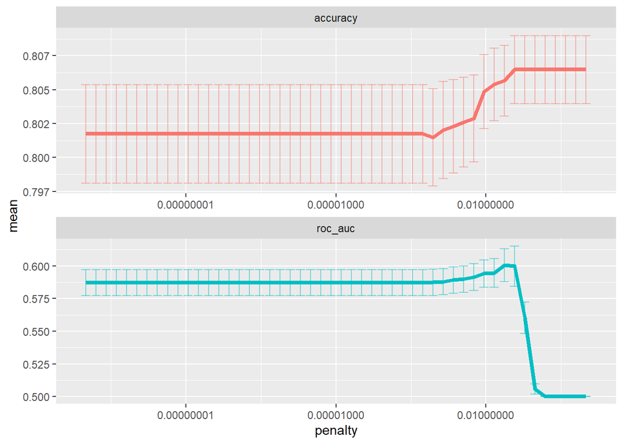

```r
echo=FALSE
error=FALSE
warning=FALSE
options(scipen = 999, digits=3, max.print=999999, show.signif.stars=TRUE)
lasso_grid %>%
  collect_metrics() %>%
  ggplot(aes(penalty, mean, color = .metric)) +
  geom_errorbar(aes(
    ymin = mean - std_err,
    ymax = mean + std_err
  ),
  alpha = 0.5
  ) +
  geom_line(size = 1.5) +
  facet_wrap(~.metric, scales = "free", nrow = 2) +
  scale_x_log10() +
  theme(legend.position = "none")
```

```r
echo=FALSE
error=FALSE
warning=FALSE
options(scipen = 999, digits=3, max.print=999999, show.signif.stars=TRUE)
Best_Lasso <- lasso_grid%>%
  select_best("accuracy", "roc_auc")
Best_Lasso
```

```
## # A tibble: 1 x 2
##   penalty .config
##     <dbl> <chr>
## 1  0.0373 Preprocessor1_Model43
```

```r
echo=FALSE
error=FALSE
warning=FALSE
options(scipen = 999, digits=3, max.print=999999, show.signif.stars=TRUE)
#Finalize the workoflow with the best LASSO
final_wflow_Lasso <-Lasso_workflow_T%>%
  finalize_workflow(Best_Lasso)
#Check the fit of the final Wflow on the training data
Tuned_Lasso_fit<-final_wflow_Lasso%>%fit(train_data_GD_b)
Tuned_Lasso_fit
```

```
## == Workflow [trained] ==========================================================
## Preprocessor: Recipe
## Model: multinom_reg()
##
## -- Preprocessor ----------------------------------------------------------------
## 5 Recipe Steps
##
## * step_smote()
## * step_zv()
## * step_nzv()
## * step_corr()
## * step_normalize()
##
## -- Model -----------------------------------------------------------------------
##
```

[output cut: 52 more lines]

```r
echo=FALSE
error=FALSE
warning=FALSE
options(scipen = 999, digits=3, max.print=999999, show.signif.stars=TRUE)
#Test the tuned Lasso on the test data
results_tuned_Lasso<-test_data_GD_b%>% select(GDDiag) %>%
  bind_cols(Tuned_Lasso_fit%>%
              predict(new_data = test_data_GD_b)) %>%
  bind_cols(Tuned_Lasso_fit%>%
              predict(new_data = test_data_GD_b, type = "prob"))
kable(results_tuned_Lasso)
```

| GDDiag | .pred_class | .pred_Yes | .pred_No |
| --- | --- | --- | --- |
| Yes | No | 0.281 | 0.719 |
| No | No | 0.180 | 0.820 |
| No | No | 0.203 | 0.797 |
| No | No | 0.167 | 0.833 |
| No | No | 0.160 | 0.840 |
| No | No | 0.188 | 0.812 |
| No | No | 0.227 | 0.773 |
| No | No | 0.210 | 0.790 |
| No | No | 0.203 | 0.797 |
| No | No | 0.195 | 0.805 |
| No | No | 0.154 | 0.846 |
| No | No | 0.235 | 0.765 |
| No | No | 0.148 | 0.852 |
| No | No | 0.235 | 0.765 |
| No | No | 0.188 | 0.812 |
| No | No | 0.173 | 0.827 |
| No | No | 0.227 | 0.773 |
| No | No | 0.160 | 0.840 |
| No | No | 0.148 | 0.852 |
| No | No | 0.167 | 0.833 |
| No | No | 0.148 | 0.852 |
| No | No | 0.188 | 0.812 |
| No | No | 0.235 | 0.765 |
| No | No | 0.180 | 0.820 |
| No | No | 0.219 | 0.781 |
| No | No | 0.253 | 0.747 |
| No | No | 0.148 | 0.852 |
| Yes | No | 0.272 | 0.728 |
| No | No | 0.160 | 0.840 |
| No | No | 0.195 | 0.805 |

[output cut: 103 more lines]

```r
#Tuned Lasso_Results
results_tuned_Lasso %>%
  conf_mat(truth = GDDiag, estimate = .pred_class)
```

```
##           Truth
## Prediction Yes  No
##        Yes   0   0
##        No   26 107
```

```r
#visualise CF
update_geom_defaults(geom = "rect", new = list(fill = "midnightblue", alpha = 0.7))
results_tuned_Lasso %>%
  conf_mat(GDDiag, .pred_class) %>%
  autoplot()
```

[output not shown]

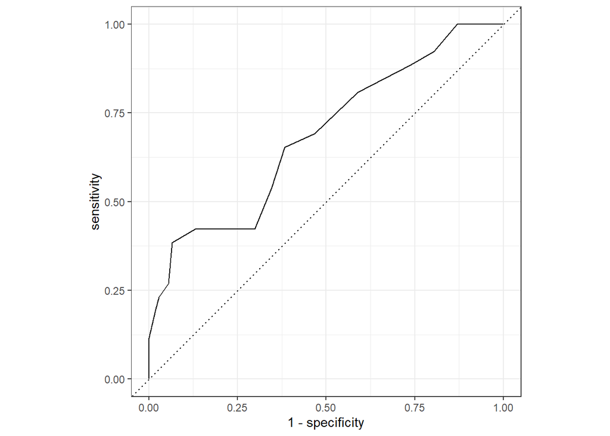

```r
#Plot Roc_Curve
curve_Lasso_tuned <- results_tuned_Lasso %>%
  roc_curve(GDDiag, .pred_Yes) %>%
  autoplot
curve_Lasso_tuned
```

```r
echo=FALSE
error=FALSE
warning=FALSE
options(scipen = 999, digits=3, max.print=999999, show.signif.stars=TRUE)
# Evaluate ROC_AOC
auc_Lasso_tuned <- results_tuned_Lasso %>%
  roc_auc(GDDiag, .pred_Yes)
auc_Lasso_tuned
```

```
## # A tibble: 1 x 3
##   .metric .estimator .estimate
##   <chr>   <chr>          <dbl>
## 1 roc_auc binary         0.684
```

```r
ev_met1_TunLasso<-ev_met1(results_tuned_Lasso,truth = GDDiag, estimate = .pred_class)
Rec_TLasso<-yardstick::recall(results_tuned_Lasso, GDDiag, .pred_class)
ACC_TLasso<-yardstick::accuracy(results_tuned_Lasso, GDDiag, .pred_class)
TunLassoMET<-list(auc_Lasso_tuned,ev_met1_TunLasso, Rec_TLasso, ACC_TLasso)
kable(TunLassoMET)
```

| .metric | .estimator | .estimate |
| --- | --- | --- |
| roc_auc | binary | 0.684 |

| .metric | .estimator | .estimate |
| --- | --- | --- |
| ppv | binary | NaN |
| f_meas | binary | NA |

| .metric | .estimator | .estimate |
| --- | --- | --- |
| recall | binary | 0 |

| .metric | .estimator | .estimate |
| --- | --- | --- |
| accuracy | binary | 0.805 |

```r
echo=FALSE
error=FALSE
warning=FALSE
options(scipen = 999, digits=3, max.print=999999, show.signif.stars=TRUE)

set.seed(123)
#Naive Bayes

#first creating a tuning model
tune_NB <- naive_Bayes(smoothness = tune(), Laplace = tune ())%>%
  set_mode("classification")%>%
  set_engine("naivebayes")


#second creating a tuning workflow
NB_workflow_T<-workflow()%>%
  add_recipe(GD_rec) %>%
  add_model(tune_NB)
#third calling the workflow
NB_workflow_T
```

```
## == Workflow ====================================================================
## Preprocessor: Recipe
## Model: naive_Bayes()
##
## -- Preprocessor ----------------------------------------------------------------
## 5 Recipe Steps
##
## * step_smote()
## * step_zv()
## * step_nzv()
## * step_corr()
## * step_normalize()
##
## -- Model -----------------------------------------------------------------------
## Naive Bayes Model Specification (classification)
##
## Main Arguments:
##   smoothness = tune()
##   Laplace = tune()
##
## Computational engine: naivebayes
```

```r
# fourth tuning/testing the workflow to the resamples
set.seed(345)
NB_grid <- grid_regular(parameters(tune_NB), levels = 20)

NB_res<- tune_grid(
  NB_workflow_T,
  resamples = folds,
  grid = NB_grid)
```

```r
#Collect metrics
echo=FALSE
error=FALSE
warning=FALSE
options(scipen = 999, digits=3, max.print=999999, show.signif.stars=TRUE)

set.seed(123)
NB_res%>%
  collect_metrics() %>%
  slice_head(n = 10)
```

```
## # A tibble: 10 x 8
##    smoothness Laplace .metric  .estimator  mean     n std_err .config
##         <dbl>   <dbl> <chr>    <chr>      <dbl> <int>   <dbl> <chr>
##  1      0.5         0 accuracy binary     0.786    10  0.0225 Preprocessor1_Mod~
##  2      0.5         0 roc_auc  binary     0.618    10  0.0276 Preprocessor1_Mod~
##  3      0.553       0 accuracy binary     0.791    10  0.0234 Preprocessor1_Mod~
##  4      0.553       0 roc_auc  binary     0.617    10  0.0296 Preprocessor1_Mod~
##  5      0.605       0 accuracy binary     0.789    10  0.0231 Preprocessor1_Mod~
##  6      0.605       0 roc_auc  binary     0.616    10  0.0316 Preprocessor1_Mod~
##  7      0.658       0 accuracy binary     0.791    10  0.0215 Preprocessor1_Mod~
##  8      0.658       0 roc_auc  binary     0.613    10  0.0320 Preprocessor1_Mod~
##  9      0.711       0 accuracy binary     0.794    10  0.0224 Preprocessor1_Mod~
## 10      0.711       0 roc_auc  binary     0.614    10  0.0338 Preprocessor1_Mod~
```

```r
echo=FALSE
error=FALSE
warning=FALSE
options(scipen = 999, digits=3, max.print=999999, show.signif.stars=TRUE)
best_NB <- NB_res %>%
  select_best("accuracy", "roc_auc")
best_NB
```

```
## # A tibble: 1 x 3
##   smoothness Laplace .config
##        <dbl>   <dbl> <chr>
## 1       1.45       0 Preprocessor1_Model019
```

```r
echo=FALSE
error=FALSE
warning=FALSE
options(scipen = 999, digits=3, max.print=999999, show.signif.stars=TRUE)
#11th Finalize the workoflow with the best model
final_wflow_NB <- NB_workflow_T %>%
  finalize_workflow(best_NB)
#12th Check the fit of the final Wflow on the training data
Tuned_NB_fit<-final_wflow_NB%>%fit(train_data_GD_b)
Tuned_NB_fit
```

```
## == Workflow [trained] ==========================================================
## Preprocessor: Recipe
## Model: naive_Bayes()
##
## -- Preprocessor ----------------------------------------------------------------
## 5 Recipe Steps
##
## * step_smote()
## * step_zv()
## * step_nzv()
## * step_corr()
## * step_normalize()
##
## -- Model -----------------------------------------------------------------------
##
## ================================== Naive Bayes ==================================
##
##  Call:
## naive_bayes.default(x = maybe_data_frame(x), y = y, laplace = ~0,
##     usekernel = TRUE, adjust = ~1.44736842105263)
##
## ---------------------------------------------------------------------------------
##
## Laplace smoothing: 0
##
## ---------------------------------------------------------------------------------
##
##  A priori probabilities:
##
## Yes  No
## 0.2 0.8
##
## ---------------------------------------------------------------------------------
##
##  Tables:
##
## ---------------------------------------------------------------------------------
##  ::: AGE::Yes (KDE)
## ---------------------------------------------------------------------------------
##
```

[output cut: 12 more lines]

```
##
## ---------------------------------------------------------------------------------
##  ::: AGE::No (KDE)
## ---------------------------------------------------------------------------------
##
## Call:
##  density.default(x = x, adjust = ..1, na.rm = TRUE)
##
## Data: x (320 obs.);  Bandwidth 'bw' = 0.3916
##
##        x               y
##  Min.   :-2.90   Min.   :0.000
##
## ...
## and 148 more lines.
```

```r
echo=FALSE
error=FALSE
warning=FALSE
options(scipen = 999, digits=3, max.print=999999, show.signif.stars=TRUE)
#Test the tuned NB on the test data
results_tuned_NB<-test_data_GD_b %>% select(GDDiag) %>%
  bind_cols (Tuned_NB_fit%>%
              predict(new_data = test_data_GD_b)) %>%
  bind_cols(Tuned_NB_fit%>%
              predict(new_data = test_data_GD_b, type = "prob"))
kable(results_tuned_NB)
```

| GDDiag | .pred_class | .pred_Yes | .pred_No |
| --- | --- | --- | --- |
| Yes | No | 0.239 | 0.761 |
| No | No | 0.158 | 0.842 |
| No | No | 0.275 | 0.725 |
| No | No | 0.039 | 0.961 |
| No | No | 0.075 | 0.925 |
| No | No | 0.071 | 0.929 |
| No | No | 0.129 | 0.871 |
| No | No | 0.192 | 0.808 |
| No | No | 0.036 | 0.964 |
| No | No | 0.084 | 0.916 |
| No | No | 0.046 | 0.954 |
| No | No | 0.175 | 0.825 |
| No | No | 0.036 | 0.964 |
| No | No | 0.134 | 0.866 |
| No | No | 0.191 | 0.809 |
| No | No | 0.127 | 0.873 |
| No | No | 0.129 | 0.871 |
| No | No | 0.064 | 0.936 |
| No | No | 0.091 | 0.909 |
| No | No | 0.062 | 0.938 |
| No | No | 0.055 | 0.945 |
| No | No | 0.282 | 0.718 |
| No | No | 0.297 | 0.703 |
| No | No | 0.108 | 0.892 |
| No | No | 0.047 | 0.953 |
| No | No | 0.397 | 0.603 |
| No | No | 0.039 | 0.961 |
| Yes | No | 0.434 | 0.566 |
| No | No | 0.044 | 0.956 |
| No | No | 0.111 | 0.889 |

[output cut: 103 more lines]

```r
echo=FALSE
error=FALSE
warning=FALSE
options(scipen = 999, digits=3, max.print=999999, show.signif.stars=TRUE)
#Tuned NB_Results
results_tuned_NB %>%
  conf_mat(truth = GDDiag, estimate = .pred_class)
```

```
##           Truth
## Prediction Yes  No
##        Yes   1   1
##        No   25 106
```

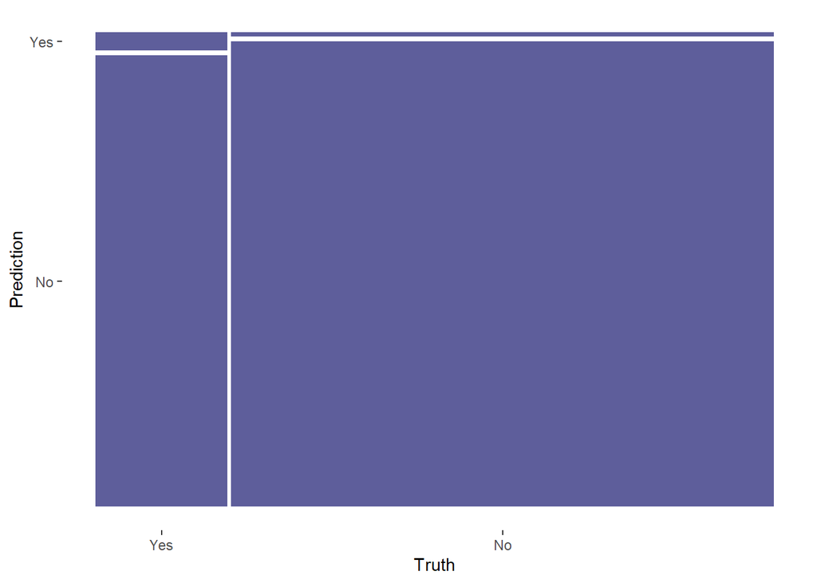

```r
#visualise CF
update_geom_defaults(geom = "rect", new = list(fill = "midnightblue", alpha = 0.7))
results_tuned_NB %>%
  conf_mat(GDDiag, .pred_class) %>%
  autoplot()
```

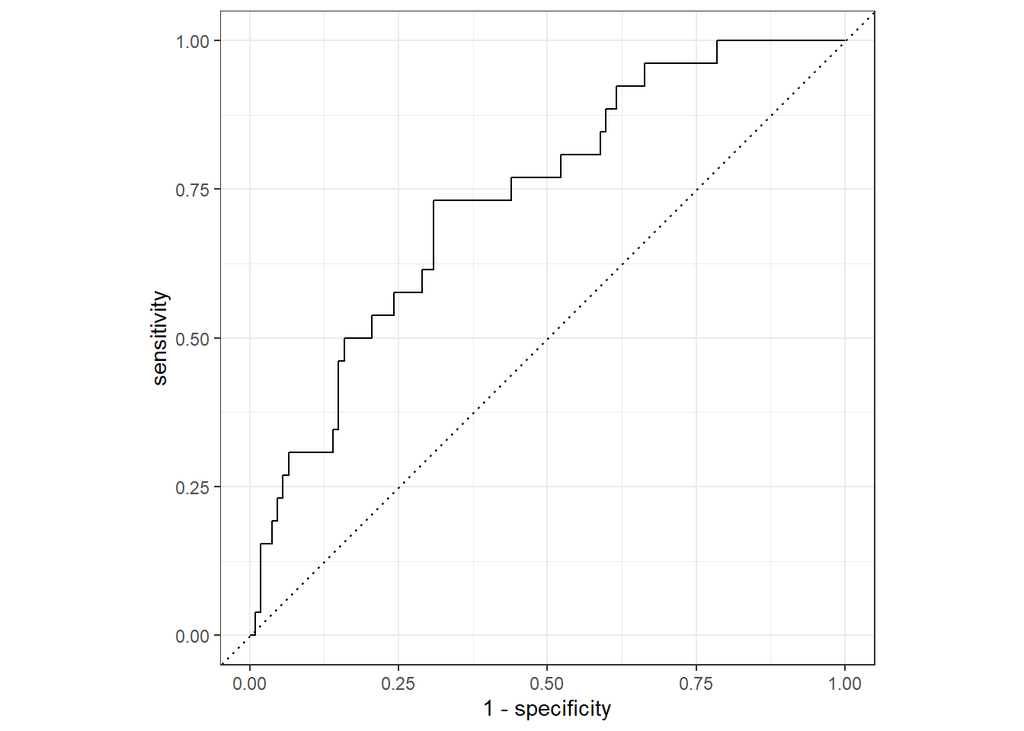

```r
echo=FALSE
error=FALSE
warning=FALSE
options(scipen = 999, digits=3, max.print=999999, show.signif.stars=TRUE)
#Plot Roc_Curve
curve_NB_tuned <- results_tuned_NB %>%
  roc_curve(GDDiag, .pred_Yes) %>%
  autoplot
curve_NB_tuned
```

```r
echo=FALSE
error=FALSE
warning=FALSE
options(scipen = 999, digits=3, max.print=999999, show.signif.stars=TRUE)
# Evaluate ROC_AUC
auc_NB_tuned <- results_tuned_NB %>%
  roc_auc(GDDiag, .pred_Yes)
auc_NB_tuned
```

```
## # A tibble: 1 x 3
##   .metric .estimator .estimate
##   <chr>   <chr>          <dbl>
## 1 roc_auc binary         0.735
```

```r
echo=FALSE
error=FALSE
warning=FALSE
options(scipen = 999, digits=3, max.print=999999, show.signif.stars=TRUE)
ev_met1_TunNB<-ev_met1(results_tuned_NB,truth = GDDiag, estimate = .pred_class)
Rec_TNB<-yardstick::recall(results_tuned_NB, GDDiag, .pred_class)
ACC_TNB<-yardstick::accuracy(results_tuned_NB, GDDiag, .pred_class)
TunNBMET<-list(auc_NB_tuned,ev_met1_TunNB, Rec_TNB, ACC_TNB)
kable(TunNBMET)
```

| .metric | .estimator | .estimate |
| --- | --- | --- |
| roc_auc | binary | 0.735 |

| .metric | .estimator | .estimate |
| --- | --- | --- |
| ppv | binary | 0.500 |
| f_meas | binary | 0.071 |

| .metric | .estimator | .estimate |
| --- | --- | --- |
| recall | binary | 0.038 |

| .metric | .estimator | .estimate |
| --- | --- | --- |
| accuracy | binary | 0.805 |

```r
echo=FALSE
error=FALSE
warning=FALSE
options(scipen = 999, digits=3, max.print=999999, show.signif.stars=TRUE)

set.seed(123)
#Logistic Regression

#first creating a tuning model
tune_LR <- logistic_reg(penalty = tune(), mixture = tune())%>%
  set_mode("classification")%>%
  set_engine("glmnet")


#second creating a tuning workflow
LR_workflow_T<-workflow()%>%
  add_recipe(GD_rec) %>%
  add_model(tune_LR)
#third calling the workflow
LR_workflow_T
```

```
## == Workflow ====================================================================
## Preprocessor: Recipe
## Model: logistic_reg()
##
## -- Preprocessor ----------------------------------------------------------------
## 5 Recipe Steps
##
## * step_smote()
## * step_zv()
## * step_nzv()
## * step_corr()
## * step_normalize()
##
## -- Model -----------------------------------------------------------------------
## Logistic Regression Model Specification (classification)
##
## Main Arguments:
##   penalty = tune()
##   mixture = tune()
##
## Computational engine: glmnet
```

```r
set.seed(345)
echo=FALSE
error=FALSE
warning=FALSE
options(scipen = 999, digits=3, max.print=999999, show.signif.stars=TRUE)

LR_grid <- grid_regular(parameters(tune_LR), levels = 20)

LR_res<- tune_grid(
  LR_workflow_T,
  resamples = folds,
  grid = LR_grid)

LR_res
```

```
## # Tuning results
## # 10-fold cross-validation
## # A tibble: 10 x 4
##    splits           id     .metrics           .notes
##    <list>           <chr>  <list>             <list>
##  1 <split [358/40]> Fold01 <tibble [800 x 6]> <tibble [0 x 3]>
##  2 <split [358/40]> Fold02 <tibble [800 x 6]> <tibble [0 x 3]>
##  3 <split [358/40]> Fold03 <tibble [800 x 6]> <tibble [0 x 3]>
##  4 <split [358/40]> Fold04 <tibble [800 x 6]> <tibble [0 x 3]>
##  5 <split [358/40]> Fold05 <tibble [800 x 6]> <tibble [0 x 3]>
##  6 <split [358/40]> Fold06 <tibble [800 x 6]> <tibble [0 x 3]>
##  7 <split [358/40]> Fold07 <tibble [800 x 6]> <tibble [0 x 3]>
##  8 <split [358/40]> Fold08 <tibble [800 x 6]> <tibble [0 x 3]>
##  9 <split [359/39]> Fold09 <tibble [800 x 6]> <tibble [0 x 3]>
## 10 <split [359/39]> Fold10 <tibble [800 x 6]> <tibble [0 x 3]>
```

```r
echo=FALSE
error=FALSE
warning=FALSE
options(scipen = 999, digits=3, max.print=999999, show.signif.stars=TRUE)

set.seed(123)
LR_res%>%
  collect_metrics() %>%
  slice_head(n = 10)
```

```
## # A tibble: 10 x 8
##     penalty mixture .metric  .estimator  mean     n std_err .config
##       <dbl>   <dbl> <chr>    <chr>      <dbl> <int>   <dbl> <chr>
##  1 1   e-10    0.05 accuracy binary     0.804    10  0.0278 Preprocessor1_Model~
##  2 1   e-10    0.05 roc_auc  binary     0.592    10  0.0673 Preprocessor1_Model~
##  3 3.36e-10    0.05 accuracy binary     0.804    10  0.0278 Preprocessor1_Model~
##  4 3.36e-10    0.05 roc_auc  binary     0.592    10  0.0673 Preprocessor1_Model~
##  5 1.13e- 9    0.05 accuracy binary     0.804    10  0.0278 Preprocessor1_Model~
##  6 1.13e- 9    0.05 roc_auc  binary     0.592    10  0.0673 Preprocessor1_Model~
##  7 3.79e- 9    0.05 accuracy binary     0.804    10  0.0278 Preprocessor1_Model~
##  8 3.79e- 9    0.05 roc_auc  binary     0.592    10  0.0673 Preprocessor1_Model~
##  9 1.27e- 8    0.05 accuracy binary     0.804    10  0.0278 Preprocessor1_Model~
## 10 1.27e- 8    0.05 roc_auc  binary     0.592    10  0.0673 Preprocessor1_Model~
```

```r
echo=FALSE
error=FALSE
warning=FALSE
options(scipen = 999, digits=3, max.print=999999, show.signif.stars=TRUE)
best_LR <- LR_res %>%
  select_best("accuracy", "roc_auc")
best_LR
```

```
## # A tibble: 1 x 3
##   penalty mixture .config
##     <dbl>   <dbl> <chr>
## 1 0.00785    0.05 Preprocessor1_Model016
```

```r
echo=FALSE
error=FALSE
warning=FALSE
options(scipen = 999, digits=3, max.print=999999, show.signif.stars=TRUE)
#11th Finalize the workoflow with the best model
final_wflow_LR <- LR_workflow_T %>%
  finalize_workflow(best_LR)
#12th Check the fit of the final Wflow on the training data
Tuned_LR_fit<-final_wflow_LR%>%fit(train_data_GD_b)
Tuned_LR_fit
```

```
## == Workflow [trained] ==========================================================
## Preprocessor: Recipe
## Model: logistic_reg()
##
## -- Preprocessor ----------------------------------------------------------------
## 5 Recipe Steps
##
## * step_smote()
## * step_zv()
## * step_nzv()
## * step_corr()
## * step_normalize()
##
## -- Model -----------------------------------------------------------------------
##
```

[output cut: 52 more lines]

```r
echo=FALSE
error=FALSE
warning=FALSE
options(scipen = 999, digits=3, max.print=999999, show.signif.stars=TRUE)
#Test the tuned NB on the test data
results_tuned_LR<-test_data_GD_b %>% select(GDDiag) %>%
  bind_cols (Tuned_LR_fit%>%
              predict(new_data = test_data_GD_b)) %>%
  bind_cols(Tuned_LR_fit%>%
              predict(new_data = test_data_GD_b, type = "prob"))
kable(results_tuned_LR)
```

| GDDiag | .pred_class | .pred_Yes | .pred_No |
| --- | --- | --- | --- |
| Yes | No | 0.467 | 0.533 |
| No | No | 0.108 | 0.892 |
| No | No | 0.174 | 0.826 |
| No | No | 0.141 | 0.859 |
| No | No | 0.143 | 0.857 |
| No | No | 0.209 | 0.791 |
| No | No | 0.206 | 0.794 |
| No | No | 0.167 | 0.833 |
| No | No | 0.186 | 0.814 |
| No | No | 0.235 | 0.765 |
| No | No | 0.091 | 0.909 |
| No | No | 0.220 | 0.780 |
| No | No | 0.114 | 0.886 |
| No | No | 0.226 | 0.774 |
| No | No | 0.181 | 0.819 |
| No | No | 0.080 | 0.920 |
| No | No | 0.212 | 0.788 |
| No | No | 0.127 | 0.873 |
| No | No | 0.116 | 0.884 |
| No | No | 0.129 | 0.871 |
| No | No | 0.119 | 0.881 |
| No | No | 0.142 | 0.858 |
| No | No | 0.228 | 0.772 |
| No | No | 0.146 | 0.854 |
| No | No | 0.255 | 0.745 |
| No | No | 0.283 | 0.717 |
| No | No | 0.136 | 0.864 |
| Yes | No | 0.279 | 0.721 |
| No | No | 0.134 | 0.866 |
| No | No | 0.142 | 0.858 |

[output cut: 103 more lines]

```r
echo=FALSE
error=FALSE
warning=FALSE
options(scipen = 999, digits=3, max.print=999999, show.signif.stars=TRUE)
#Tuned NB_Results
results_tuned_LR %>%
  conf_mat(truth = GDDiag, estimate = .pred_class)
```

```
##           Truth
## Prediction Yes  No
##        Yes   0   0
##        No   26 107
```

```r
#visualise CF
update_geom_defaults(geom = "rect", new = list(fill = "midnightblue", alpha = 0.7))
results_tuned_LR %>%
  conf_mat(GDDiag, .pred_class) %>%
  autoplot()
```

[output not shown]

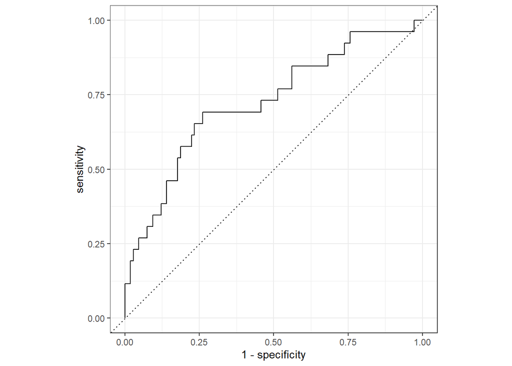

```r
echo=FALSE
error=FALSE
warning=FALSE
options(scipen = 999, digits=3, max.print=999999, show.signif.stars=TRUE)
#Plot Roc_Curve
curve_LR_tuned <- results_tuned_LR%>%
  roc_curve(GDDiag, .pred_Yes) %>%
  autoplot
curve_LR_tuned
```

```r
echo=FALSE
error=FALSE
warning=FALSE
options(scipen = 999, digits=3, max.print=999999, show.signif.stars=TRUE)
# Evaluate ROC_AUC
auc_LR_tuned <- results_tuned_LR %>%
  roc_auc(GDDiag, .pred_Yes)
auc_LR_tuned
```

```
## # A tibble: 1 x 3
##   .metric .estimator .estimate
##   <chr>   <chr>          <dbl>
## 1 roc_auc binary         0.724
```

```r
echo=FALSE
error=FALSE
warning=FALSE
options(scipen = 999, digits=3, max.print=999999, show.signif.stars=TRUE)
ev_met1_TunLR<-ev_met1(results_tuned_LR,truth = GDDiag, estimate = .pred_class)
Rec_TLR<-yardstick::recall(results_tuned_LR, GDDiag, .pred_class)
ACC_TLR<-yardstick::accuracy(results_tuned_LR, GDDiag, .pred_class)
TunLRMET<-list(auc_LR_tuned,ev_met1_TunLR, Rec_TLR, ACC_TLR)
kable(TunLRMET)
```

| .metric | .estimator | .estimate |
| --- | --- | --- |
| roc_auc | binary | 0.724 |

| .metric | .estimator | .estimate |
| --- | --- | --- |
| ppv | binary | NaN |
| f_meas | binary | NA |

| .metric | .estimator | .estimate |
| --- | --- | --- |
| recall | binary | 0 |

| .metric | .estimator | .estimate |
| --- | --- | --- |
| accuracy | binary | 0.805 |

```r
echo=FALSE
error=FALSE
warning=FALSE
options(scipen = 999, digits=3, max.print=999999, show.signif.stars=TRUE)

set.seed(123)
#xgb_tree

#first creating a tuning model
tune_xgb_t <- boost_tree(
  trees = 1000,
  tree_depth = tune(), min_n = tune(),
  loss_reduction = tune(),                     ## first three: model complexity
  sample_size = tune(), mtry = tune(),         ## randomness
  learn_rate = tune()                          ## step size
) %>%
  set_engine("xgboost") %>%
  set_mode("classification")


#second creating a tuning workflow
xgb_workflow_T<-workflow()%>%
  add_recipe(GD_rec) %>%
  add_model(tune_xgb_t)
#third calling the workflow
xgb_workflow_T
```

```
## == Workflow ====================================================================
## Preprocessor: Recipe
## Model: boost_tree()
##
## -- Preprocessor ----------------------------------------------------------------
## 5 Recipe Steps
##
## * step_smote()
## * step_zv()
## * step_nzv()
## * step_corr()
## * step_normalize()
##
## -- Model -----------------------------------------------------------------------
## Boosted Tree Model Specification (classification)
##
## Main Arguments:
##   mtry = tune()
##   trees = 1000
##   min_n = tune()
##   tree_depth = tune()
##   learn_rate = tune()
##   loss_reduction = tune()
##   sample_size = tune()
##
## Computational engine: xgboost
```

```r
set.seed(345)
echo=FALSE
error=FALSE
warning=FALSE
options(scipen = 999, digits=3, max.print=999999, show.signif.stars=TRUE)

xgb_grid <- grid_latin_hypercube(
  tree_depth(),
  min_n(),
  loss_reduction(),
  sample_size = sample_prop(),
  finalize(mtry(), train_data_GD_b),
  learn_rate(),
  size = 30
)

xgb_res<- tune_grid(
  xgb_workflow_T,
  resamples = folds,
  grid = xgb_grid)

xgb_res
```

```
## # Tuning results
## # 10-fold cross-validation
## # A tibble: 10 x 4
##    splits           id     .metrics           .notes
##    <list>           <chr>  <list>             <list>
##  1 <split [358/40]> Fold01 <tibble [60 x 10]> <tibble [0 x 3]>
##  2 <split [358/40]> Fold02 <tibble [60 x 10]> <tibble [0 x 3]>
##  3 <split [358/40]> Fold03 <tibble [60 x 10]> <tibble [0 x 3]>
##  4 <split [358/40]> Fold04 <tibble [60 x 10]> <tibble [0 x 3]>
##  5 <split [358/40]> Fold05 <tibble [60 x 10]> <tibble [0 x 3]>
##  6 <split [358/40]> Fold06 <tibble [60 x 10]> <tibble [0 x 3]>
##  7 <split [358/40]> Fold07 <tibble [60 x 10]> <tibble [0 x 3]>
##  8 <split [358/40]> Fold08 <tibble [60 x 10]> <tibble [0 x 3]>
##  9 <split [359/39]> Fold09 <tibble [60 x 10]> <tibble [0 x 3]>
## 10 <split [359/39]> Fold10 <tibble [60 x 10]> <tibble [0 x 3]>
```

```r
set.seed(345)
echo=FALSE
error=FALSE
warning=FALSE
options(scipen = 999, digits=3, max.print=999999, show.signif.stars=TRUE)

set.seed(123)
xgb_res%>%
  collect_metrics() %>%
  slice_head(n = 10)
```

```
## # A tibble: 10 x 12
##     mtry min_n tree_depth    learn_rate loss_reduction sample_size .metric
##    <int> <int>      <int>         <dbl>          <dbl>       <dbl> <chr>
##  1     3    29          5 0.0000000133   0.000000749         0.674 accuracy
##  2     3    29          5 0.0000000133   0.000000749         0.674 roc_auc
##  3     1    12         10 0.00000000155  0.00000000245       0.898 accuracy
##  4     1    12         10 0.00000000155  0.00000000245       0.898 roc_auc
##  5     6     7          5 0.0000137      0.0000000203        0.372 accuracy
##  6     6     7          5 0.0000137      0.0000000203        0.372 roc_auc
##  7     1     3         11 0.00268        0.495               0.336 accuracy
##  8     1     3         11 0.00268        0.495               0.336 roc_auc
##  9     2    16         13 0.0000547      0.0229              0.955 accuracy
## 10     2    16         13 0.0000547      0.0229              0.955 roc_auc
## # i 5 more variables: .estimator <chr>, mean <dbl>, n <int>, std_err <dbl>,
## #   .config <chr>
```

```r
set.seed(345)
echo=FALSE
error=FALSE
warning=FALSE
options(scipen = 999, digits=3, max.print=999999, show.signif.stars=TRUE)

best_xgb <- xgb_res%>%
  select_best("accuracy", "roc_auc")
best_xgb
```

```
## # A tibble: 1 x 7
##    mtry min_n tree_depth   learn_rate loss_reduction sample_size .config
##   <int> <int>      <int>        <dbl>          <dbl>       <dbl> <chr>
## 1     3    29          5 0.0000000133    0.000000749       0.674 Preprocessor1_~
```

```r
echo=FALSE
error=FALSE
warning=FALSE
options(scipen = 999, digits=3, max.print=999999, show.signif.stars=TRUE)
#11th Finalize the workoflow with the best model
final_wflow_xgb <- xgb_workflow_T %>%
  finalize_workflow(best_xgb)
#12th Check the fit of the final Wflow on the training data
Tuned_xgb_fit<-final_wflow_xgb%>%fit(train_data_GD_b)
Tuned_xgb_fit
```

```
## == Workflow [trained] ==========================================================
## Preprocessor: Recipe
## Model: boost_tree()
##
## -- Preprocessor ----------------------------------------------------------------
## 5 Recipe Steps
##
## * step_smote()
## * step_zv()
## * step_nzv()
## * step_corr()
## * step_normalize()
##
## -- Model -----------------------------------------------------------------------
## ##### xgb.Booster
## raw: 709.9 Kb
## call:
##   xgboost::xgb.train(params = list(eta = 0.0000000132996844924202,
##     max_depth = 5L, gamma = 0.000000748907218707958, colsample_bytree = 1,
##     colsample_bynode = 0.5, min_child_weight = 29L, subsample = 0.674093100563623),
##     data = x$data, nrounds = 1000, watchlist = x$watchlist, verbose = 0,
##     nthread = 1, objective = "binary:logistic")
## params (as set within xgb.train):
##   eta = "0.0000000132996844924202", max_depth = "5", gamma = "0.000000748907218707958", colsample_bytree = "1", colsample_bynode = "0.5", min_child_weight = "29", subsample = "0.674093100563623", nthread = "1", objective = "binary:logistic", validate_parameters = "TRUE"
## xgb.attributes:
##   niter
## callbacks:
##   cb.evaluation.log()
## # of features: 6
## niter: 1000
## nfeatures : 6
## evaluation_log:
##     iter training_logloss
##        1            0.693
##        2            0.693
## ---
##      999            0.693
##     1000            0.693
```

```r
echo=FALSE
error=FALSE
warning=FALSE
options(scipen = 999, digits=3, max.print=999999, show.signif.stars=TRUE)
#Test the tuned NB on the test data
results_tuned_xgb<-test_data_GD_b %>% select(GDDiag) %>%
  bind_cols (Tuned_xgb_fit%>%
              predict(new_data = test_data_GD_b)) %>%
  bind_cols(Tuned_xgb_fit%>%
              predict(new_data = test_data_GD_b, type = "prob"))
kable(results_tuned_xgb)
```

| GDDiag | .pred_class | .pred_Yes | .pred_No |
| --- | --- | --- | --- |
| Yes | No | 0.5 | 0.5 |
| No | No | 0.5 | 0.5 |
| No | No | 0.5 | 0.5 |
| No | No | 0.5 | 0.5 |
| No | No | 0.5 | 0.5 |
| No | No | 0.5 | 0.5 |
| No | No | 0.5 | 0.5 |
| No | No | 0.5 | 0.5 |
| No | No | 0.5 | 0.5 |
| No | No | 0.5 | 0.5 |
| No | No | 0.5 | 0.5 |
| No | No | 0.5 | 0.5 |
| No | No | 0.5 | 0.5 |
| No | No | 0.5 | 0.5 |
| No | No | 0.5 | 0.5 |
| No | No | 0.5 | 0.5 |
| No | No | 0.5 | 0.5 |
| No | No | 0.5 | 0.5 |
| No | No | 0.5 | 0.5 |
| No | No | 0.5 | 0.5 |
| No | No | 0.5 | 0.5 |
| No | No | 0.5 | 0.5 |
| No | No | 0.5 | 0.5 |
| No | No | 0.5 | 0.5 |
| No | No | 0.5 | 0.5 |
| No | No | 0.5 | 0.5 |
| No | No | 0.5 | 0.5 |
| Yes | No | 0.5 | 0.5 |
| No | No | 0.5 | 0.5 |
| No | No | 0.5 | 0.5 |

[output cut: 103 more lines]

```r
echo=FALSE
error=FALSE
warning=FALSE
options(scipen = 999, digits=3, max.print=999999, show.signif.stars=TRUE)

#Tuned xgb_Results
results_tuned_xgb %>%
  conf_mat(truth = GDDiag, estimate = .pred_class)
```

```
##           Truth
## Prediction Yes  No
##        Yes   0   0
##        No   26 107
```

```r
#visualise CF
update_geom_defaults(geom = "rect", new = list(fill = "midnightblue", alpha = 0.7))
results_tuned_xgb %>%
  conf_mat(GDDiag, .pred_class) %>%
  autoplot()
```

[output not shown]

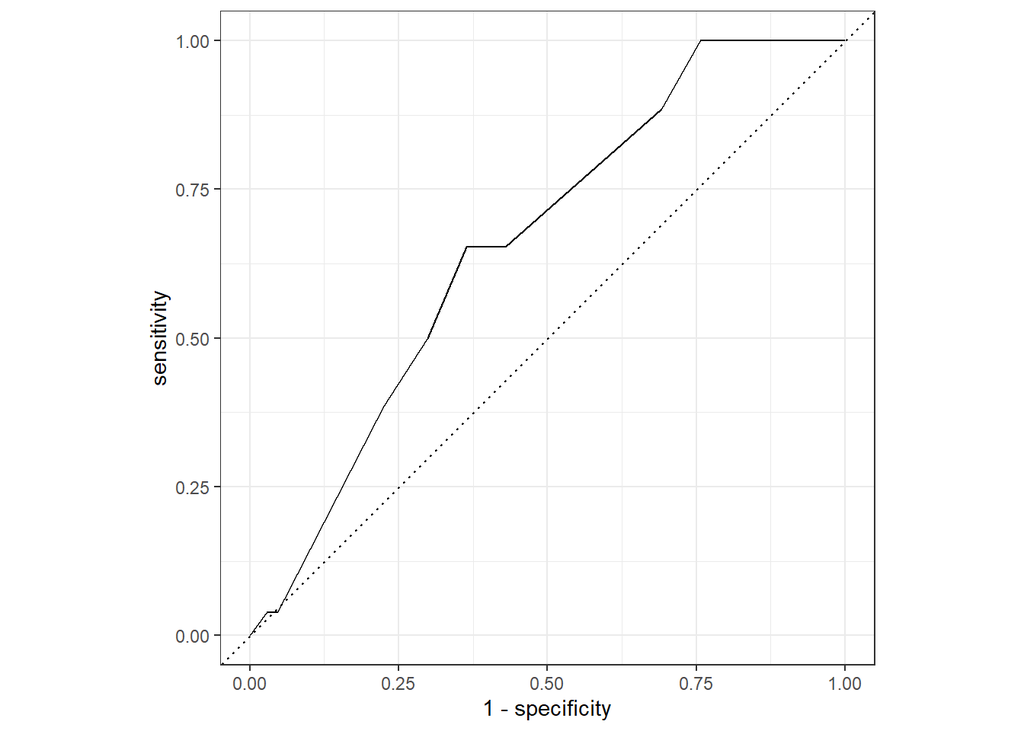

```r
echo=FALSE
error=FALSE
warning=FALSE
options(scipen = 999, digits=3, max.print=999999, show.signif.stars=TRUE)
#Plot Roc_Curve
curve_xgb_tuned <- results_tuned_xgb%>%
  roc_curve(GDDiag, .pred_Yes) %>%
  autoplot
curve_xgb_tuned
```

```r
echo=FALSE
error=FALSE
warning=FALSE
options(scipen = 999, digits=3, max.print=999999, show.signif.stars=TRUE)
# Evaluate ROC_AUC
auc_xgb_tuned <- results_tuned_xgb %>%
  roc_auc(GDDiag, .pred_Yes)
auc_xgb_tuned
```

```
## # A tibble: 1 x 3
##   .metric .estimator .estimate
##   <chr>   <chr>          <dbl>
## 1 roc_auc binary         0.658
```

```r
echo=FALSE
error=FALSE
warning=FALSE
options(scipen = 999, digits=3, max.print=999999, show.signif.stars=TRUE)
ev_met1_Tunxgb<-ev_met1(results_tuned_xgb,truth = GDDiag, estimate = .pred_class)
Rec_Txgb<-yardstick::recall(results_tuned_xgb, GDDiag, .pred_class)
ACC_Txgb<-yardstick::accuracy(results_tuned_xgb, GDDiag, .pred_class)
TunxgbMET<-list(auc_xgb_tuned,ev_met1_Tunxgb, Rec_Txgb, ACC_Txgb)
kable(TunxgbMET)
```

| .metric | .estimator | .estimate |
| --- | --- | --- |
| roc_auc | binary | 0.658 |

| .metric | .estimator | .estimate |
| --- | --- | --- |
| ppv | binary | NaN |
| f_meas | binary | NA |

| .metric | .estimator | .estimate |
| --- | --- | --- |
| recall | binary | 0 |

| .metric | .estimator | .estimate |
| --- | --- | --- |
| accuracy | binary | 0.805 |

[output not shown]